# Reproducibility notebook — An empirical anatomy of retail panic buying: PBB-Score construction, temporal cross-validation, and dynamic responses

Companion code to the manuscript submitted to *Computers & Industrial Engineering* (Special Issue: AI in Logistics)

Compiled 17 July 2026

This notebook reproduces, end to end, the empirical pipeline behind the paper. It is the documented counterpart of the production script `Temporal_CV_v9.R`, reorganised so that a reader can follow *what* is computed, *why* each choice was made, and *what* the result is, without having to reverse-engineer the code.

The notebook is organised in **seven parts**:

1. **Constructing the PBB-Score** — from raw fiscal-receipt transaction values to a dimensionless, city-standardised measure of abnormal purchasing.
2. **Why the evaluation protocol matters** — the methodological core of the paper: what a random train–test split does to temporally autocorrelated panel data.
3. **Expanding-window temporal cross-validation** — a three-way horse race between an autoregressive baseline, an external open-data model, and their combination.
4. **Early-warning evaluation** — recasting the forecasts as a rare-event alarm system (AUC-PR, AUC-ROC, threshold selection, lead time).
5. **Model interpretation with SHAP** — which stimuli and organism variables the model uses.
6. **Local Projections** — the dynamic, crisis-conditional response of the PBB-Score to S-O-R shocks.
7. **Episode anatomy** — the descriptive natural history of panic-buying episodes.

> **A note on faithfulness to `Temporal_CV_v9.R`.** The production script grew interactively and contains diagnostic detours that were subsequently reverted. The most consequential is a sequence of alternative winsorisation fences for the municipality of Curitibanos (2.5× IQR, then 2.0× IQR), which is undone before the final model is fitted: the script resets Curitibanos to its raw values and re-applies exactly the same 3× IQR fence used for every other city. That detour is therefore a **no-op**, and the linear pipeline below reproduces the final numerical state of `Temporal_CV_v9.R` exactly. The one substantive change made along the way — adding 30 December to the holiday calendar — is preserved, including the fact that it was applied *after* the `is_pre_holiday` flag had already been computed (see “Holiday calendar” below).

# 1 Environment and project layout

```r
required <- c(
  "data.table", "dplyr", "readxl", "lubridate",   # data handling
  "fixest", "car",                                # panel econometrics
  "xgboost", "caret", "treeshap", "PRROC",        # machine learning + SHAP + PR curves
  "sidrar",                                       # IBGE/SIDRA API (price deflator)
  "ggplot2", "patchwork", "scales", "knitr"       # graphics and reporting
)
missing <- required[!(required %in% rownames(installed.packages()))]
if (length(missing)) {
  message("Installing: ", paste(missing, collapse = ", "))
  install.packages(missing, repos = "https://cloud.r-project.org")
}
invisible(lapply(required, library, character.only = TRUE))
```

Paths are taken from the YAML `params` block, so the notebook can be knitted from any checkout of the repository without editing code. **No `setwd()` is used**: `knitr` sets the working directory to the folder containing this file.

```r
DATA_DIR <- "data/input/"#params$data_dir
PROC_DIR <- "data/input/"#params$proc_dir
OUT_DIR  <- "data/analysis/"#params$out_dir

for (d in c(PROC_DIR, OUT_DIR,
            file.path(OUT_DIR, "PDFs"),
            file.path(OUT_DIR, "temporal_cv_ar_augmented", "ar_only"),
            file.path(OUT_DIR, "temporal_cv_ar_augmented", "external_only"),
            file.path(OUT_DIR, "temporal_cv_ar_augmented", "combined"),
            file.path(OUT_DIR, "classification_three_way"),
            file.path(OUT_DIR, "local_projections"),
            file.path(OUT_DIR, "episode_anatomy"),
            file.path(OUT_DIR, "Shap"))) {
  if (!dir.exists(d)) dir.create(d, recursive = TRUE)
}

RAW_XLSX     <- file.path(DATA_DIR, "2_5_Final_data_Before_Time_modification_and_new_variables.xlsx")
PANEL_CSV    <- file.path(PROC_DIR, "3_Final_data_With_Time_modification_ADDED_Var.csv")
DEFLATOR_CSV <- file.path(PROC_DIR, "deflator_alimentacao_domicilio_2018_2025.csv")
BEST_ROW     <- file.path(OUT_DIR,  "best_row.csv")

stopifnot("Raw workbook not found — check params$data_dir" = file.exists(RAW_XLSX))
```

Expensive steps (grid search, 12-fold × 3-model cross-validation, SHAP) write `.rds` caches and are skipped on re-knit if the cache exists. Setting `run_heavy: FALSE` in the YAML forces the notebook to *only* read caches, which makes a full re-knit take seconds instead of hours.

```r
RUN_HEAVY <- isTRUE(params$run_heavy)
cat("Heavy computation:", if (RUN_HEAVY) "ENABLED" else "DISABLED (cache-only)", "\n")
```

```
## Heavy computation: ENABLED
```

# 2 Part 1 — Constructing the PBB-Score

The dependent variable of the whole paper is the **Panic Buying Behaviour Score (PBB-Score)**, also referred to in the code as the **Abnormal Purchase Index (API)**. It is defined as

$$\text{PBB}_{c,t} \;=\; \frac{\tilde V_{c,t} - \hat
V_{c,t}}{\hat\sigma_c},$$

where $\tilde V_{c,t}$ is real per-capita daily supermarket spending in city $c$ on day $t$, $\hat V_{c,t}$ is the expected value from a seasonal baseline model estimated on non-crisis days only, and $\hat\sigma_c$ is the city-specific standard deviation of that model’s residuals on non-crisis days.

The construction is deliberately analogous to **abnormal returns in a finance event study**: the score is dimensionless, centred on zero in normal times, and directly readable as “standard deviations above what this city would ordinarily spend today”.

## 2.1 Raw panel and sanity checks

```r
# IMPORTANT: readxl guesses each column's type from the first `guess_max` rows. The
# mobility series (Meta Movement Distribution Maps) are blank until 2022-12, so with
# the default guess_max readxl infers type `logical` for them and silently coerces
# every later numeric value to NA. We raise guess_max to cover the full panel, then
# defensively coerce any mobility / numeric-looking column that still arrived as
# logical or character back to numeric. This is the fix for the empty Mobilization
# Local-Projections panel.
raw <- readxl::read_excel(RAW_XLSX, guess_max = 1e6)
dt  <- as.data.table(raw)
dt[, date := as.Date(date)]

coerce_numeric <- function(x) {
  if (is.numeric(x)) return(x)
  if (is.logical(x)) return(as.numeric(x))            # all-NA logical -> numeric NA, values kept
  suppressWarnings(as.numeric(gsub(",", ".", as.character(x), fixed = TRUE)))
}
mob_cols <- grep("^mobil_dist", names(dt), value = TRUE)
for (cc in mob_cols) dt[[cc]] <- coerce_numeric(dt[[cc]])

# Report mobility coverage at the point of entry so any problem is visible immediately.
if (length(mob_cols)) {
  nn <- sum(!is.na(dt[[mob_cols[1]]]))
  cat(sprintf("Mobility columns: %s | %s non-NA rows in %s%s\n",
              paste(mob_cols, collapse = ", "), format(nn, big.mark = ","), mob_cols[1],
              if (nn > 0) sprintf(" (%s .. %s)",
                                  min(dt$date[!is.na(dt[[mob_cols[1]]])]),
                                  max(dt$date[!is.na(dt[[mob_cols[1]]])])) else ""))
}
```

```
## Mobility columns: mobil_dist_0, mobil_dist_0_10km, mobil_dist_100km_plus, mobil_dist_10_100km | 14,770 non-NA rows in mobil_dist_0 (2022-12-01 .. 2025-12-31)
```

```r
cat(sprintf("Rows            : %s\n", format(nrow(dt), big.mark = ",")))
```

```
## Rows            : 43,827
```

```r
cat(sprintf("Municipalities  : %d\n", uniqueN(dt$city)))
```

```
## Municipalities  : 15
```

```r
cat(sprintf("Date range      : %s to %s\n", min(dt$date), max(dt$date)))
```

```
## Date range      : 2018-01-01 to 2025-12-31
```

```r
cat(sprintf("Missing sales   : %d\n", sum(is.na(dt$total_sales_value_daily))))
```

```
## Missing sales   : 0
```

## 2.2 Per-capita normalisation

```r
dt[, valor_pc := total_sales_value_daily / population_2022]
summary(dt$valor_pc)
```

```
##    Min. 1st Qu.  Median    Mean 3rd Qu.    Max.
##    0.00   10.10   15.42   17.54   21.39 7734.09
```

We normalise by the **2022 census population**, not by the number of invoices issued (`numero_de_notas_emitidas`). This is not a cosmetic choice: the invoice count is *endogenous* to the phenomenon we are measuring — panic buying mechanically inflates the number of transactions — so using it as a denominator would partially absorb the very signal we are trying to detect. It can legitimately enter the baseline as a *regressor* controlling for store activity, but never as a scaling factor.

## 2.3 Real-value deflation

Nominal spending in Brazil over 2018–2025 is contaminated by substantial food inflation. We deflate with the **IPCA sub-index for food consumed at home** (*Alimentação no domicílio*), which is the correct price index for supermarket baskets — not headline IPCA.

The series is stitched from two IBGE/SIDRA tables (1419 for 2018–2019, 7060 from 2020 onward), chained from monthly percentage changes into an index with January 2018 = 100.

```r
pt_months <- c("janeiro" = "01", "fevereiro" = "02", "março"    = "03",
               "abril"   = "04", "maio"      = "05", "junho"    = "06",
               "julho"   = "07", "agosto"    = "08", "setembro" = "09",
               "outubro" = "10", "novembro"  = "11", "dezembro" = "12")

parse_pt_date <- function(x) {
  parts <- strsplit(tolower(trimws(x)), "\\s+")
  as.Date(sapply(parts, function(p) {
    if (length(p) != 2) return(NA_character_)
    mon <- pt_months[p[1]]
    if (is.na(mon)) return(NA_character_)
    paste0(p[2], "-", mon, "-01")
  }))
}

get_col <- function(d, pattern, exclude = NULL) {
  cols <- grep(pattern, names(d), value = TRUE, ignore.case = TRUE)
  if (!is.null(exclude)) cols <- cols[!grepl(exclude, cols, ignore.case = TRUE)]
  cols[1]
}

clean_filter <- function(rawtab, label_col, mes_col, target) {
  d <- as.data.table(rawtab)[get(label_col) == target]
  d <- d[, .(year_month = parse_pt_date(as.character(get(mes_col))),
             var_mes    = suppressWarnings(as.numeric(Valor)))]
  d <- d[!is.na(year_month) & !is.na(var_mes)]
  setorder(d, year_month)
  d[]
}

fetch_food_deflator <- function() {
  raw_7060 <- sidrar::get_sidra(x = 7060, variable = 63, period = "202001-202512",
                                geo = "Brazil", classific = "c315",
                                category = list("315" = "all"), header = TRUE, format = 3)
  raw_1419 <- sidrar::get_sidra(x = 1419, variable = 63, period = "201801-201912",
                                geo = "Brazil", classific = "c315",
                                category = list("315" = "all"), header = TRUE, format = 3)

  pick_label <- function(tab) {
    d   <- as.data.table(tab)
    cc  <- get_col(d, "Geral|subgrupo|subitem")
    mc  <- get_col(d, "Mês|Mes", exclude = "Código|Code")
    lab <- unique(d[[cc]])
    tgt <- lab[grepl("Alimenta.*no domic", lab, ignore.case = TRUE)]
    stopifnot(length(tgt) > 0)
    list(cat_col = cc, mes_col = mc, target = tgt[1])
  }
  k70 <- pick_label(raw_7060); k14 <- pick_label(raw_1419)

  s7060 <- clean_filter(raw_7060, k70$cat_col, k70$mes_col, k70$target)
  s1419 <- clean_filter(raw_1419, k14$cat_col, k14$mes_col, k14$target)

  a <- rbind(s1419[year_month <  as.Date("2020-01-01")],
             s7060[year_month >= as.Date("2020-01-01")])
  setorder(a, year_month)
  a[, factor   := 1 + var_mes / 100]
  a[, alim_idx := cumprod(factor) * 100 / cumprod(factor)[1]]
  a[, deflator := alim_idx / 100]
  a[]
}

if (isTRUE(params$fetch_sidra)) {
  alim <- tryCatch(fetch_food_deflator(), error = function(e) {
    message("SIDRA API unavailable (", conditionMessage(e), ") — falling back to cached CSV.")
    NULL
  })
} else {
  alim <- NULL
}

if (is.null(alim)) {
  stopifnot("No SIDRA access and no cached deflator CSV present" = file.exists(DEFLATOR_CSV))
  alim <- fread(DEFLATOR_CSV)
  alim[, year_month := as.Date(year_month)]
  setnames(alim, c("var_mes_pct", "index_jan2018_100"), c("var_mes", "alim_idx"),
           skip_absent = TRUE)
} else {
  fwrite(alim[, .(year_month, var_mes_pct = var_mes,
                  index_jan2018_100 = alim_idx, deflator)], DEFLATOR_CSV)
}

# Continuity check: no missing months
expected <- seq.Date(as.Date("2018-01-01"), max(alim$year_month), by = "month")
gaps     <- expected[!expected %in% alim$year_month]
cat(if (length(gaps) == 0) "Continuous monthly series — OK\n"
    else paste("Missing months:", paste(gaps, collapse = ", "), "\n"))
```

```
## Continuous monthly series — OK
```

The cumulative food-price drift is large enough that ignoring it would introduce a spurious upward trend into the “abnormality” measure:

```r
knitr::kable(
  alim[month(year_month) == 1, .(Month = year_month,
                                 `Monthly %` = round(var_mes, 2),
                                 `Index (Jan-2018 = 100)` = round(alim_idx, 1),
                                 Deflator = round(deflator, 3))],
  caption = "IPCA — Food at home: index level each January"
)
```

IPCA — Food at home: index level each January

| Month | Monthly % | Index (Jan-2018 = 100) | Deflator |
| --- | --- | --- | --- |
| 2018-01-01 | 1.12 | 100.0 | 1.000 |
| 2019-01-01 | 0.97 | 104.4 | 1.044 |
| 2020-01-01 | 0.20 | 111.7 | 1.117 |
| 2021-01-01 | 1.06 | 133.1 | 1.331 |
| 2022-01-01 | 1.44 | 144.6 | 1.446 |
| 2023-01-01 | 0.60 | 162.3 | 1.623 |
| 2024-01-01 | 1.81 | 163.4 | 1.634 |
| 2025-01-01 | 1.07 | 175.6 | 1.756 |

```r
if ("deflator" %in% names(dt)) dt[, deflator := NULL]
dt[, year_month := as.Date(paste0(format(date, "%Y-%m"), "-01"))]
dt <- merge(dt, alim[, .(year_month, deflator)], by = "year_month", all.x = TRUE)

n_miss <- sum(is.na(dt$deflator))
if (n_miss > 0) {
  stop(sprintf(paste("Deflator missing for %d rows. The IPCA series ends %s while the",
                     "panel ends %s. Extend the SIDRA `period` argument."),
               n_miss, max(alim$year_month), max(dt$date)))
}
cat("Deflator matched for all", format(nrow(dt), big.mark = ","), "rows.\n")
```

```
## Deflator matched for all 43,827 rows.
```

```r
dt[, valor_pc_real := valor_pc / deflator]

# data.table's merge reorders rows by the join key. Every subsequent operation that uses
# shift() (the pre-holiday flag, the S_/O_ lags) assumes strict within-city chronological
# order, so we re-impose it here explicitly rather than relying on the merge's stability.
setorder(dt, city, date)

summary(dt$valor_pc_real)
```

```
##     Min.  1st Qu.   Median     Mean  3rd Qu.     Max.
##    0.000    7.044   11.474   12.835   15.845 4278.120
```

## 2.4 The crisis calendar

The baseline model must describe what a city spends *in normal times*. If crisis days were included in its estimation sample, the model would learn to “expect” panic and the resulting residuals would be attenuated exactly where we need them to be large. We therefore hold out a calendar of **known macro-shocks** — pandemic waves, trucker strikes and blockades, and Santa Catarina climate events.

An important honesty point for the paper: these windows come from an **event calendar**, not from any signal-based detection. The PBB-Score is not claimed to *discover* regimes; it measures deviation from a calm-period norm.

The calendar is defined **once**, as a typed data frame, and every downstream use — the baseline hold-out, the shaded bands in Figure 4, the Local Projection regimes, and the episode attribution in Part 7 — is derived from this single object. In the production script these four uses each carried their own hard-coded copy of the dates, which is how they drifted apart (see the note at the end of this subsection).

```r
crisis_calendar <- data.frame(
  event = c(
    # --- Pandemic waves ---
    "covid_wave_1", "covid_wave_2", "covid_wave_3",
    # --- Geopolitical ---
    "trucker_strike_2018", "trucker_strike_2021", "trucker_blockades_2022",
    # --- Climate ---
    "sc_ciclone_bomba_floripa_2020", "sc_chuvas_fortes_2020", "sc_chuvas_600mm_2021",
    "sc_alto_vale_storm_2021", "sc_grande_floripa_alto_vale_2021",
    "sc_chuvas_estado_sul_2022", "sc_cyclone_2022", "sc_norte_joinville_2022",
    "sc_bc_itapema_2022", "sc_vale_itajai_bc_2023", "sc_estado_50pct_afetado_2023",
    "sc_vale_itajai_2023", "sc_floods_2023", "sc_bc_itapema_2024",
    "sc_grande_floripa_2025"
  ),
  type = c(rep("pandemic", 3), rep("geopolitical", 3), rep("climate", 15)),
  start = as.Date(c(
    "2020-02-25", "2020-11-16", "2021-11-16",
    "2018-05-21", "2021-09-07", "2022-10-31",
    "2020-06-30", "2020-12-17", "2021-01-21", "2021-03-26", "2021-06-08",
    "2022-05-03", "2022-09-28", "2022-11-29", "2022-12-20", "2023-01-17",
    "2023-10-10", "2023-11-11", "2023-11-17", "2024-01-08", "2025-12-08"
  )),
  end = as.Date(c(
    "2020-09-26", "2021-09-16", "2022-04-01",
    "2018-05-31", "2021-09-09", "2022-11-02",
    "2020-07-01", "2020-12-21", "2021-01-24", "2021-03-26", "2021-06-09",
    "2022-05-05", "2022-10-05", "2022-12-04", "2022-12-22", "2023-01-18",
    "2023-10-10", "2023-11-14", "2023-11-30", "2024-01-16", "2025-12-10"
  )),
  stringsAsFactors = FALSE
)
stopifnot(all(crisis_calendar$end >= crisis_calendar$start))

# Helper reused throughout the notebook
in_calendar <- function(d, cal) {
  Reduce(`|`, Map(function(s, e) d >= s & d <= e, cal$start, cal$end))
}

dt[, is_crisis := in_calendar(date, crisis_calendar)]

cat(sprintf("Events in calendar               : %d (%d pandemic, %d geopolitical, %d climate)\n",
            nrow(crisis_calendar), sum(crisis_calendar$type == "pandemic"),
            sum(crisis_calendar$type == "geopolitical"),
            sum(crisis_calendar$type == "climate")))
```

```
## Events in calendar               : 21 (3 pandemic, 3 geopolitical, 15 climate)
```

```r
cat(sprintf("Crisis days (held out of baseline): %s (%.1f%%)\n",
            format(sum(dt$is_crisis), big.mark = ","), 100 * mean(dt$is_crisis)))
```

```
## Crisis days (held out of baseline): 10,860 (24.8%)
```

```r
cat(sprintf("Calm days (baseline training)     : %s\n",
            format(sum(!dt$is_crisis), big.mark = ",")))
```

```
## Calm days (baseline training)     : 32,967
```

Canonical crisis calendar

| event | type | start | end | days |
| --- | --- | --- | --- | --- |
| trucker_strike_2018 | geopolitical | 2018-05-21 | 2018-05-31 | 11 |
| covid_wave_1 | pandemic | 2020-02-25 | 2020-09-26 | 215 |
| sc_ciclone_bomba_floripa_2020 | climate | 2020-06-30 | 2020-07-01 | 2 |
| covid_wave_2 | pandemic | 2020-11-16 | 2021-09-16 | 305 |
| sc_chuvas_fortes_2020 | climate | 2020-12-17 | 2020-12-21 | 5 |
| sc_chuvas_600mm_2021 | climate | 2021-01-21 | 2021-01-24 | 4 |
| sc_alto_vale_storm_2021 | climate | 2021-03-26 | 2021-03-26 | 1 |
| sc_grande_floripa_alto_vale_2021 | climate | 2021-06-08 | 2021-06-09 | 2 |
| trucker_strike_2021 | geopolitical | 2021-09-07 | 2021-09-09 | 3 |
| covid_wave_3 | pandemic | 2021-11-16 | 2022-04-01 | 137 |
| sc_chuvas_estado_sul_2022 | climate | 2022-05-03 | 2022-05-05 | 3 |
| sc_cyclone_2022 | climate | 2022-09-28 | 2022-10-05 | 8 |
| trucker_blockades_2022 | geopolitical | 2022-10-31 | 2022-11-02 | 3 |
| sc_norte_joinville_2022 | climate | 2022-11-29 | 2022-12-04 | 6 |
| sc_bc_itapema_2022 | climate | 2022-12-20 | 2022-12-22 | 3 |
| sc_vale_itajai_bc_2023 | climate | 2023-01-17 | 2023-01-18 | 2 |
| sc_estado_50pct_afetado_2023 | climate | 2023-10-10 | 2023-10-10 | 1 |
| sc_vale_itajai_2023 | climate | 2023-11-11 | 2023-11-14 | 4 |
| sc_floods_2023 | climate | 2023-11-17 | 2023-11-30 | 14 |
| sc_bc_itapema_2024 | climate | 2024-01-08 | 2024-01-16 | 9 |
| sc_grande_floripa_2025 | climate | 2025-12-08 | 2025-12-10 | 3 |

> **Discrepancy inherited from `Temporal_CV_v9.R`, and how it is handled here.** The production script defines this calendar in four separate places, and they are not identical. The baseline hold-out uses all 15 climate windows; the Local Projections block and the episode-anatomy block each use a hard-coded list that **omits `sc_cyclone_2022` and `sc_floods_2023`**; Figure 4’s shaded bands are a third, hand-tuned set of `annotate()` literals. This notebook derives everything from `crisis_calendar`, but ships with a switch (`V9_CLIMATE_OMISSIONS`, in Part 6) that reproduces v9’s omission exactly, so the published LP and episode numbers still replicate. **This is a decision you need to make before submission**: either the two windows belong in the regime definitions (in which case the LP and episode tables must be re-run) or they do not (in which case they should also be removed from the baseline hold-out).

## 2.5 Calendar and seasonality features

```r
dt[, `:=`(
  time_linear = as.numeric(date),
  date_year   = year(date),
  date_month  = month(date),
  date_wday   = wday(date),     # 1 = Sunday ... 7 = Saturday
  date_yday   = yday(date),
  is_weekend  = as.integer(wday(date) %in% c(1, 7))
)]

# Harmonic projections (retained for the ML feature set, not used in the OLS baseline)
dt[, `:=`(
  month_sin = sin(2 * pi * date_month / 12), month_cos = cos(2 * pi * date_month / 12),
  wday_sin  = sin(2 * pi * date_wday  / 7),  wday_cos  = cos(2 * pi * date_wday  / 7),
  yday_sin  = sin(2 * pi * date_yday  / 365.25), yday_cos = cos(2 * pi * date_yday / 365.25)
)]

dt[, time_linear_c := time_linear - min(time_linear)]
dt[, dow_f   := factor(date_wday)]
dt[, month_f := factor(date_month)]

# Within-month payday cycle: two harmonics plus indicators for the 1st and the 31st
dt[, dom      := mday(date)]
dt[, dom_sin  := sin(2 * pi * dom / 31)]
dt[, dom_cos  := cos(2 * pi * dom / 31)]
dt[, dom_sin2 := sin(4 * pi * dom / 31)]
dt[, dom_cos2 := cos(4 * pi * dom / 31)]
dt[, is_day31 := mday(date) == 31]
dt[, is_day1  := mday(date) == 1]
```

The within-month cycle deserves a word. Brazilian retail spending has a strong payday rhythm (private-sector wages early in the month, public-sector salaries at month end). An initial specification used blunt `is_start_of_month` / `is_end_of_month` dummies; the residual plot by day-of-month showed these were too coarse, and they were replaced by two Fourier harmonics of the day-of-month cycle plus explicit dummies for the 1st and the 31st (the 31st being structurally special because only seven months have one).

## 2.6 Holiday calendar

```r
holidays_base <- as.Date(c(
  # Fixed national holidays
  paste0(2018:2025, "-01-01"), paste0(2018:2025, "-04-21"), paste0(2018:2025, "-05-01"),
  paste0(2018:2025, "-09-07"), paste0(2018:2025, "-10-12"), paste0(2018:2025, "-11-02"),
  paste0(2018:2025, "-11-15"), "2024-11-20", "2025-11-20",
  paste0(2018:2025, "-12-24"), paste0(2018:2025, "-12-25"), paste0(2018:2025, "-12-31"),
  # Fixed commercial dates
  paste0(2018:2025, "-03-15"),   # Dia do Consumidor
  paste0(2018:2025, "-06-12"),   # Dia dos Namorados
  paste0(2018:2025, "-09-15"),   # Dia do Cliente
  # Carnival (Mon + Tue)
  "2018-02-12","2018-02-13","2019-03-04","2019-03-05","2020-02-24","2020-02-25",
  "2021-02-15","2021-02-16","2022-02-28","2022-03-01","2023-02-20","2023-02-21",
  "2024-02-12","2024-02-13","2025-03-03","2025-03-04",
  # Good Friday
  "2018-03-30","2019-04-19","2020-04-10","2021-04-02",
  "2022-04-15","2023-04-07","2024-03-29","2025-04-18",
  # Corpus Christi
  "2018-05-31","2019-06-20","2020-06-11","2021-06-03",
  "2022-06-16","2023-06-08","2024-05-30","2025-06-19",
  # Mother's Day
  "2018-05-13","2019-05-12","2020-05-10","2021-05-09",
  "2022-05-08","2023-05-14","2024-05-12","2025-05-11",
  # Father's Day
  "2018-08-12","2019-08-11","2020-08-09","2021-08-08",
  "2022-08-14","2023-08-13","2024-08-11","2025-08-10",
  # Black Friday
  "2018-11-23","2019-11-29","2020-11-27","2021-11-26",
  "2022-11-25","2023-11-24","2024-11-29","2025-11-28"
))

# --- Order of operations, preserved from Temporal_CV_v9.R ---------------------
# The pre-holiday ("bridge day") flag is built from the BASE calendar.
dt[, is_holiday := date %in% holidays_base]
dt[, is_pre_holiday := shift(is_holiday, n = 1, type = "lead"), by = city]
dt[is.na(is_pre_holiday), is_pre_holiday := FALSE]

# 30 December was added to the holiday set AFTER residual diagnostics revealed a
# systematic year-end spike. In v9 the pre-holiday flag was NOT rebuilt afterwards;
# we keep that behaviour so the numbers reproduce exactly.
holidays <- c(holidays_base, as.Date(paste0(2018:2025, "-12-30")))
dt[, is_holiday := date %in% holidays]

cat(sprintf("Holidays flagged: %d unique dates | pre-holiday (bridge) days: %d\n",
            length(unique(holidays)), sum(dt$is_pre_holiday)))
```

```
## Holidays flagged: 170 unique dates | pre-holiday (bridge) days: 2415
```

> **Known inconsistency, flagged for the record.** Because 30 December enters `is_holiday` after `is_pre_holiday` has been computed, 29 December is *not* treated as a bridge day. This is inherited from the production script and preserved here so that the published figures reproduce bit-for-bit. Rebuilding `is_pre_holiday` from the final calendar would change $\hat V$, $\hat\sigma_c$ and every downstream number; if you want to clean it up, it must be done as a deliberate re-run, not silently.

## 2.7 Winsorisation

Retail panels contain occasional non-behavioural spikes (bulk institutional purchases, reporting artefacts). Left untreated they inflate $\hat\sigma_c$, which *deflates* every PBB-Score in that city — the opposite of what we want. We winsorise at a **3 × IQR upper fence computed per city on calm-period observations only**, so that crisis days cannot set their own ceiling.

```r
train0 <- dt[is_crisis == FALSE & !is.na(valor_pc_real)]

upper_fence <- train0[, {
  q <- quantile(valor_pc_real, c(0.25, 0.75), na.rm = TRUE)
  .(upper_iqr = q[2] + 3 * (q[2] - q[1]))
}, by = city]

if ("upper_iqr" %in% names(dt)) dt[, upper_iqr := NULL]
dt <- merge(dt, upper_fence, by = "city", all.x = TRUE)

dt[, valor_pc_real_raw := valor_pc_real]
dt[, is_outlier := !is.na(valor_pc_real) & valor_pc_real > upper_iqr]
dt[is_outlier == TRUE, valor_pc_real := upper_iqr]

cat(sprintf("Observations winsorised: %d (%.2f%% of the panel)\n",
            sum(dt$is_outlier, na.rm = TRUE), 100 * mean(dt$is_outlier, na.rm = TRUE)))
```

```
## Observations winsorised: 304 (0.69% of the panel)
```

```r
knitr::kable(upper_fence[order(-upper_iqr)],
             col.names = c("Municipality", "Upper fence (real BRL p.c.)"),
             digits = 2, caption = "City-specific 3 × IQR upper fences (calm periods)")
```

City-specific 3 × IQR upper fences (calm periods)

| Municipality | Upper fence (real BRL p.c.) |
| --- | --- |
| Rio Negrinho | 52.29 |
| Araranguá | 47.22 |
| Lages | 40.52 |
| Joaçaba | 37.56 |
| Indaial | 36.74 |
| Curitibanos | 35.42 |
| Florianópolis | 34.75 |
| Xanxerê | 33.68 |
| Chapecó | 31.96 |
| Itajaí | 29.07 |
| Campos Novos | 25.80 |
| Itapoá | 25.58 |
| Laguna | 25.12 |
| Caçador | 22.58 |
| São Miguel do Oeste | 14.93 |

## 2.8 The baseline model $\hat V_{c,t}$

```r
train <- dt[is_crisis == FALSE & !is.na(valor_pc_real)]

baseline_model <- feols(
  valor_pc_real ~ time_linear_c + dow_f + month_f +
    is_holiday + is_pre_holiday + is_day31 + is_day1 +
    dom_sin + dom_cos + dom_sin2 + dom_cos2,
  data    = train,
  fixef   = "city",
  cluster = "city"
)
summary(baseline_model)
```

```
## OLS estimation, Dep. Var.: valor_pc_real
## Observations: 32,967
## Fixed-effects: city: 15
## Standard-errors: Clustered (city)
##                     Estimate Std. Error   t value         Pr(>|t|)
## time_linear_c      -0.002475   0.000394 -6.279410 0.00002024133327 ***
## dow_f2              2.693464   0.679743  3.962477 0.00141661389403 **
## dow_f3              3.409984   0.657803  5.183902 0.00013860851986 ***
## dow_f4              3.492975   0.639085  5.465587 0.00008320214011 ***
## dow_f5              4.231904   0.697149  6.070297 0.00002885226860 ***
## dow_f6              6.668703   0.768473  8.677863 0.00000052478848 ***
## dow_f7              9.107018   0.647700 14.060547 0.00000000119384 ***
## month_f2            0.208589   0.308532  0.676070 0.51001119127072
## month_f3           -0.518551   0.431574 -1.201536 0.24947564107587
## month_f4           -0.377103   0.493475 -0.764178 0.45744798583496
## month_f5           -0.781569   0.506268 -1.543784 0.14493897082718
## month_f6           -0.724083   0.520349 -1.391532 0.18578067094840
## month_f7           -0.690747   0.479116 -1.441713 0.17137779799278
## month_f8           -0.644939   0.533573 -1.208717 0.24679109098067
## month_f9           -0.113989   0.533712 -0.213578 0.83395499766871
## month_f10           0.347400   0.517538  0.671255 0.51298220595533
## month_f11           0.781320   0.489563  1.595954 0.13281840237495
## month_f12           2.699456   0.441568  6.113342 0.00002680878345 ***
## is_holidayTRUE     -1.503709   0.357289 -4.208667 0.00087566702204 ***
## is_pre_holidayTRUE  2.936681   0.205689 14.277283 0.00000000097640 ***
## is_day31TRUE        2.215605   0.233022  9.508150 0.00000017382934 ***
## is_day1TRUE        -1.296765   0.165463 -7.837206 0.00000173830923 ***
## dom_sin             0.911833   0.109472  8.329397 0.00000085351678 ***
## dom_cos             0.835041   0.054771 15.246144 0.00000000041026 ***
## dom_sin2            0.178488   0.049009  3.641954 0.00266705827541 **
## dom_cos2           -0.078488   0.045907 -1.709728 0.10937709983621
## ---
## Signif. codes:  0 '***' 0.001 '**' 0.01 '*' 0.05 '.' 0.1 ' ' 1
## RMSE: 4.17798     Adj. R2: 0.605263
##                 Within R2: 0.464456
```

City fixed effects absorb persistent scale differences between municipalities; the day-of-week and month factors absorb the two dominant seasonal cycles; `time_linear_c` absorbs the secular real trend; the holiday and day-of-month terms absorb the calendar structure of retail demand.

Month dummies are jointly significant by a wide margin, so they stay in:

```r
car::linearHypothesis(baseline_model,
                      grep("month_f", names(coef(baseline_model)), value = TRUE))
```

|  | Res.Df | Df | Chisq | Pr(>Chisq) |
| --- | --- | --- | --- | --- |
| 1 | 32937 | NA | NA | NA |
| 2 | 32926 | 11 | 602.7475 | 0.00000000000000000000000000000000000000000000000000000000000000000000000000000000000000000000000000000000000000000000000003619772 |

A useful diagnostic: mean residual by day of month should be flat if the payday cycle has been absorbed.

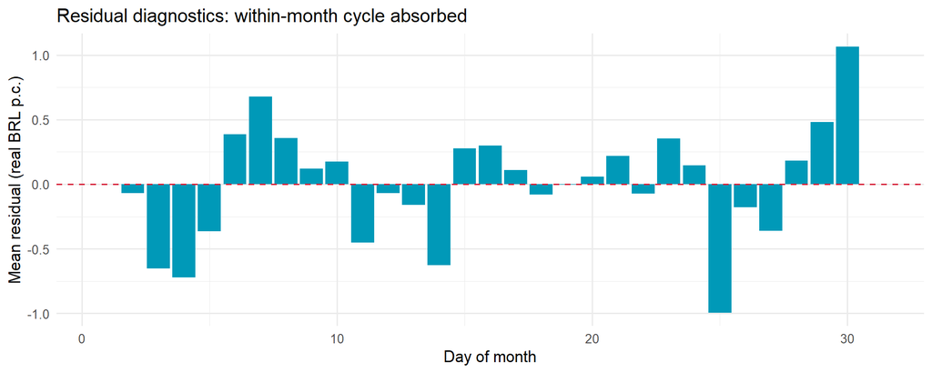

```r
train[, resid_train := valor_pc_real - predict(baseline_model, newdata = train)]
train[, .(mean_resid = mean(resid_train, na.rm = TRUE)), by = dom] |>
  ggplot(aes(dom, mean_resid)) +
  geom_col(fill = "#0099B8") +
  geom_hline(yintercept = 0, linetype = "dashed", colour = "#D7263D") +
  labs(x = "Day of month", y = "Mean residual (real BRL p.c.)",
       title = "Residual diagnostics: within-month cycle absorbed") +
  theme_minimal(base_size = 11)
```

## 2.9 City-specific dispersion $\hat\sigma_c$ and the score

```r
dt[, yhat     := predict(baseline_model, newdata = dt)]
dt[, residual := valor_pc_real - yhat]

# sigma_c is the SD of the baseline residuals on CALM days only, city by city.
# (resid_train was already attached to `train` in the diagnostic chunk above.)
city_sigma <- train[, .(sigma_c = sd(resid_train, na.rm = TRUE)), by = city]

if ("sigma_c" %in% names(dt)) dt[, sigma_c := NULL]
dt <- merge(dt, city_sigma, by = "city", all.x = TRUE)

# Two residual outliers in Caçador (Sep 2025) survive winsorisation because they sit
# below the city fence but far above the model's expectation. They are set to the
# expected value, i.e. assigned a PBB-Score of exactly zero.
dt[city == "Caçador" & date %in% as.Date(c("2025-09-23", "2025-09-24")),
   valor_pc_real := yhat]

dt[, residual := valor_pc_real - yhat]
dt[, API      := residual / sigma_c]      # <- the PBB-Score

knitr::kable(city_sigma[order(-sigma_c)], digits = 2,
             col.names = c("Municipality", "sigma_c (real BRL p.c.)"),
             caption = "City-specific residual standard deviation on calm days")
```

City-specific residual standard deviation on calm days

| Municipality | sigma_c (real BRL p.c.) |
| --- | --- |
| Rio Negrinho | 6.73 |
| Araranguá | 6.71 |
| Curitibanos | 4.75 |
| Indaial | 4.49 |
| Lages | 4.08 |
| Itapoá | 3.84 |
| Joaçaba | 3.75 |
| Xanxerê | 3.68 |
| São Miguel do Oeste | 3.68 |
| Itajaí | 3.52 |
| Florianópolis | 3.43 |
| Chapecó | 3.40 |
| Laguna | 2.75 |
| Campos Novos | 2.65 |
| Caçador | 2.48 |

```r
round(quantile(dt$API, c(.01, .05, .25, .50, .75, .90, .95, .99), na.rm = TRUE), 3)
```

```
##     1%     5%    25%    50%    75%    90%    95%    99%
## -2.284 -1.387 -0.478  0.057  0.605  1.250  1.811  3.453
```

## 2.10 Ordinal categories and face validity

```r
dt[, API_cat := fcase(
  API <  -1.0,              "Below Normal",
  API >= -1.0 & API < 1.0,  "Normal",
  API >=  1.0 & API < 2.0,  "Elevated",
  API >=  2.0 & API < 3.0,  "Panic",
  API >=  3.0,              "Extreme Panic",
  default = NA_character_
)]
dt[, API_cat := factor(API_cat,
                       levels = c("Below Normal", "Normal", "Elevated",
                                  "Panic", "Extreme Panic"), ordered = TRUE)]

cat_tab <- dt[!is.na(API_cat), .N, by = API_cat][order(API_cat)]
cat_tab[, share := sprintf("%.2f%%", 100 * N / sum(N))]
knitr::kable(cat_tab, caption = "Distribution of PBB-Score categories")
```

Distribution of PBB-Score categories

| API_cat | N | share |
| --- | --- | --- |
| Below Normal | 4613 | 10.53% |
| Normal | 33006 | 75.31% |
| Elevated | 4427 | 10.10% |
| Panic | 1119 | 2.55% |
| Extreme Panic | 662 | 1.51% |

The critical validation is not statistical but *substantive*: do score spikes line up with events that actually happened? The aggregate series answers that directly.

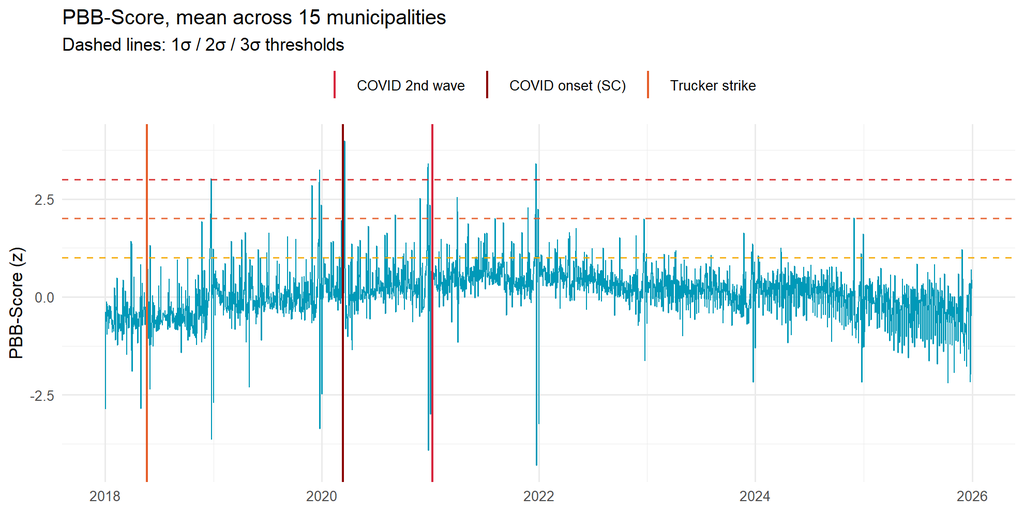

```r
daily_api <- dt[, .(API_mean = mean(API, na.rm = TRUE)), by = date]

events <- data.frame(
  date  = as.Date(c("2018-05-21", "2020-03-13", "2021-01-08")),
  label = c("Trucker strike", "COVID onset (SC)", "COVID 2nd wave")
)

ggplot(daily_api, aes(date, API_mean)) +
  geom_line(colour = "#0099B8", linewidth = 0.35) +
  geom_hline(yintercept = c(1, 2, 3), linetype = "dashed",
             colour = c("#f4a800", "#E65F2B", "#d62728"), alpha = 0.85) +
  geom_vline(data = events, aes(xintercept = date, colour = label), linewidth = 0.7) +
  scale_colour_manual(values = c("#D7263D", "#8B0000", "#E65F2B")) +
  labs(x = NULL, y = "PBB-Score (z)", colour = NULL,
       title = "PBB-Score, mean across 15 municipalities",
       subtitle = "Dashed lines: 1σ / 2σ / 3σ thresholds") +
  theme_minimal(base_size = 11) +
  theme(legend.position = "top")
```

The March-2020 spike is unmistakable, and the 2018 trucker strike is visible at the left edge — the score behaves as a panic detector should.

## 2.11 Lag structure and export

Two design decisions embed the S-O-R logic into the data itself:

- **Stimulus (`S_`) variables are lagged by two days.** A stimulus (a cyclone, a case count, a strike announcement) reaches the consumer with a reporting delay; using contemporaneous values would leak same-day information a real early-warning system could not have.
- **Organism (`O_`) variables are lagged by one day.** These capture the consumer’s internal state (search behaviour, mobility, news exposure), which mediates between stimulus and response and is observable one day ahead.

```r
final_before <- as.data.frame(dt)
write.csv2(final_before, file.path(PROC_DIR, "2_Final_data_Before_Time_modification.csv"),
           row.names = FALSE, fileEncoding = "UTF-8")

# Re-read through the CSV boundary so that column types match the production pipeline
fd <- as.data.table(read.csv2(file.path(PROC_DIR, "2_Final_data_Before_Time_modification.csv"),
                              fileEncoding = "UTF-8"))
fd[, date := as.Date(date)]

# --- Guard the round-trip -----------------------------------------------------
# write.csv2 uses a comma as the decimal mark. If any numeric series (mobility in
# particular) is read back as character — e.g. locale mismatch turning "0,83" into
# text — coerce it back to numeric here rather than letting it silently become all
# NA downstream. We only touch columns that are entirely numeric-or-NA once parsed,
# so genuine text columns (city) are left alone.
num_from_csv2 <- function(x) {
  if (is.numeric(x)) return(x)
  if (is.logical(x)) return(as.numeric(x))   # mostly-NA numeric round-tripped as logical
  y <- suppressWarnings(as.numeric(gsub(",", ".", x, fixed = TRUE)))
  # keep the coercion only if it doesn't destroy real information
  if (mean(is.na(y)) <= mean(is.na(x)) + 1e-9) y else x
}
raw_mobil <- grep("^mobil_dist", names(fd), value = TRUE)
for (cc in c(raw_mobil, grep("_daily$|_count_|_Gtrends$|_z$|_log$", names(fd), value = TRUE)))
  if (cc %in% names(fd)) fd[[cc]] <- num_from_csv2(fd[[cc]])

# Mobility and store-format series are re-labelled into the Organism block
setnames(fd,
         old = c("mobil_dist_0", "mobil_dist_0_10km", "mobil_dist_10_100km",
                 "mobil_dist_100km_plus", "hypermarket_total_sales_value_daily",
                 "supermarket_total_sales_value_daily", "minimarket_total_sales_value_daily"),
         new = c("O_mobil_dist_0", "O_mobil_dist_0_10km", "O_mobil_dist_10_100km",
                 "O_mobil_dist_100km_plus", "O_hypermarket_total_sales_value_daily",
                 "O_supermarket_total_sales_value_daily", "O_minimarket_total_sales_value_daily"),
         skip_absent = TRUE)

# Fail loudly AT THE SOURCE if mobility did not survive, instead of surfacing 1,000
# lines later as an empty Local-Projections panel. If this triggers, the mobility
# columns are absent or empty in the RAW workbook — a data-provisioning problem that
# no downstream code change can fix (run diagnostics.R to confirm the provenance).
if ("O_mobil_dist_0" %in% names(fd)) {
  nn <- sum(!is.na(fd$O_mobil_dist_0))
  cat(sprintf("Mobility check: O_mobil_dist_0 has %s non-missing values%s\n",
              format(nn, big.mark = ","),
              if (nn > 0) sprintf(" (%s .. %s)",
                                  min(fd$date[!is.na(fd$O_mobil_dist_0)]),
                                  max(fd$date[!is.na(fd$O_mobil_dist_0)])) else ""))
  if (nn == 0)
    warning("O_mobil_dist_0 is entirely NA after the round-trip. The Mobilization LP ",
            "panel will be empty. Check that the RAW workbook actually contains ",
            "populated 'mobil_dist_*' columns (see diagnostics.R, Part B).")
} else {
  cat("Mobility check: no 'mobil_dist_0' column found in the raw workbook.\n")
}
```

```
## Mobility check: O_mobil_dist_0 has 14,770 non-missing values (2022-12-01 .. 2025-12-31)
```

```r
# Crisis-regime dummy exposed to the models as a stimulus
fd[, S_is_crisis_period := as.integer(is_crisis)]

setorder(fd, city, date)
stimuli  <- grep("^S_", names(fd), value = TRUE)
organism <- grep("^O_", names(fd), value = TRUE)

fd[, (stimuli)  := lapply(.SD, shift, n = 2L, type = "lag"), by = city, .SDcols = stimuli]
fd[, (organism) := lapply(.SD, shift, n = 1L, type = "lag"), by = city, .SDcols = organism]

write.csv2(fd, PANEL_CSV, row.names = FALSE, fileEncoding = "UTF-8")

cat(sprintf("Modelling panel written: %s\n  %s rows x %d columns | %d S_ | %d O_\n",
            PANEL_CSV, format(nrow(fd), big.mark = ","), ncol(fd),
            length(stimuli), length(organism)))
```

```
## Modelling panel written: data/input//3_Final_data_With_Time_modification_ADDED_Var.csv
##   43,827 rows x 94 columns | 17 S_ | 15 O_
```

# 3 Part 2 — Why the evaluation protocol is the finding

Before any model is fitted, it is worth stating plainly what this paper’s methodological contribution is, because everything in Part 3 is designed to test it.

The PBB-Score is a **daily, city-level, strongly autocorrelated** series. If you split such a panel into training and test sets *at random* — the default in almost every applied ML paper, including several in this literature — then for essentially every test observation there exists a training observation from the *same city on an adjacent day*. The model does not have to forecast anything: it can interpolate between two neighbours it has already seen. The resulting $R^2$ measures **interpolation skill**, not **forecasting skill**, and it is systematically and severely optimistic.

Two things follow, and they are the spine of the paper:

1. Any claim that external open data (Google Trends, mobility, news, weather) constitute an early-warning system must be evaluated **out-of-time**, not out-of-sample-at-random.
2. Any such claim must be benchmarked against the **cheapest possible competitor**: the target’s own recent history. If four autoregressive lags do as well, the elaborate external-data architecture has not earned its keep.

Part 3 implements both.

# 4 Part 3 — Expanding-window temporal cross-validation

## 4.1 Design

```r
INITIAL_TRAIN_END <- as.Date("2019-12-31")   # two full pre-pandemic years
FOLD_STEP_MONTHS  <- 6                       # test block length
VAL_WINDOW_DAYS   <- 90                      # internal validation = last 90 d of training
LAG_PERIODS       <- c(1, 7, 14, 28)         # AR lags of the PBB-Score
PANIC_THRESHOLD   <- 2.0                     # PBB >= 2σ defines a "panic" day
```

- **Expanding window**, not rolling: the training set grows, mimicking an operator who accumulates history and never discards it.
- **Six-month test blocks**, always strictly in the future of the training data.
- **Early stopping on an internal validation split** (the last 90 days of each training window), so the number of boosting rounds is chosen without ever touching test data.

## 4.2 Loading the modelling panel and building AR lags

```r
df_raw <- read.csv2(PANEL_CSV, fileEncoding = "UTF-8")
df_raw$date <- as.Date(df_raw$date)

cols_to_drop <- c(
  "year_month", "upper_iqr", "valor_pc_real_raw", "residual", "yhat",
  "is_crisis", "sigma_c", "population_2022", "date_year",
  "valor_pc", "valor_pc_real", "time_linear", "time_linear_c", "is_outlier", "deflator",
  "month_sin", "month_cos", "wday_sin", "wday_cos", "yday_sin", "yday_cos",
  "dom_sin", "dom_cos", "dom_sin2", "dom_cos2",
  "is_holiday", "is_pre_holiday", "dom", "is_day31", "is_day1", "dow_f",
  "month_f", "is_weekend", "date_month", "date_wday", "date_yday",
  "S_precip_daily", "S_is_crisis_period",
  "S_pandemic_cases_z", "S_pandemic_deaths_z", "S_pandemic_cases_shock",
  "S_pandemic_deaths_shock", "S_pandemic_severity_index",
  "ecf_sales_value_daily", "nfce_sales_value_daily", "nfe_sales_value_daily",
  "total_sales_value_daily",
  "hypermarket_ecf_sales_value_daily", "hypermarket_nfc_sales_value_daily",
  "hypermarket_nf_sales_value_daily",
  "O_hypermarket_total_sales_value_daily", "O_supermarket_total_sales_value_daily",
  "O_minimarket_total_sales_value_daily",
  "minimarket_ecf_sales_value_daily", "minimarket_nfc_sales_value_daily",
  "minimarket_nf_sales_value_daily",
  "supermarket_ecf_sales_value_daily", "supermarket_nfc_sales_value_daily",
  "supermarket_nf_sales_value_daily",
  "nfce_count_daily", "nfe_count_daily",
  "hypermarket_nfce_count_daily", "hypermarket_nfe_count_daily",
  "minimarket_nfe_count_daily", "minimarket_nfce_count_daily",
  "supermarket_nfe_count_daily", "supermarket_nfce_count_daily",
  "sales_value_per_capita", "API_cat"
)
df <- df_raw %>% dplyr::select(-any_of(cols_to_drop))
```

Everything mechanically derived from the sales series is dropped. This is not fastidiousness: `valor_pc_real`, `residual` and `yhat` are the *ingredients* of the target, and leaving any of them in the feature matrix would let the model reconstruct the label algebraically. Only genuinely **external** signals and the calendar survive.

```r
# Pandemic indicators are structurally zero before 2020, not missing
pandemic_vars <- grep("^S_pandemic", names(df), value = TRUE)
df[, pandemic_vars] <- lapply(df[, pandemic_vars], function(x) replace(x, is.na(x), 0))

char_cols <- names(df)[sapply(df, is.character) & !(names(df) %in% c("date", "city"))]
for (col in char_cols) df[[col]] <- as.numeric(as.factor(df[[col]]))

TARGET <- "API"
df <- df %>% dplyr::arrange(city, date)

# AR lags are built WITHIN city — never across the panel boundary
for (k in LAG_PERIODS) {
  df <- df %>%
    dplyr::group_by(city) %>%
    dplyr::mutate(!!sprintf("lag_%d_API", k) := dplyr::lag(.data[[TARGET]], n = k)) %>%
    dplyr::ungroup()
}

valid_idx    <- !is.na(df[[TARGET]])
df_model     <- df[valid_idx, ]
dates_model  <- df_model$date
cities_model <- df_model$city

lag_cols <- sprintf("lag_%d_API", LAG_PERIODS)
for (col in lag_cols) df_model[[col]][is.na(df_model[[col]])] <- 0

all_cols          <- setdiff(names(df_model), c("date", "city"))
feature_pool      <- setdiff(all_cols, TARGET)
ar_features       <- lag_cols
external_features <- setdiff(feature_pool, ar_features)
combined_features <- feature_pool

cat(sprintf("Rows with valid target : %s\n", format(nrow(df_model), big.mark = ",")))
```

```
## Rows with valid target : 43,827
```

```r
cat(sprintf("AR-only features       : %d  (%s)\n",
            length(ar_features), paste(ar_features, collapse = ", ")))
```

```
## AR-only features       : 4  (lag_1_API, lag_7_API, lag_14_API, lag_28_API)
```

```r
cat(sprintf("External-only features : %d\n", length(external_features)))
```

```
## External-only features : 22
```

```r
cat(sprintf("Combined features      : %d\n", length(combined_features)))
```

```
## Combined features      : 26
```

## 4.3 Fold-aware target reconstruction — the subtle leakage

This is the step that most temporal-CV implementations get wrong, and it is worth dwelling on.

The PBB-Score computed in Part 1 was standardised **once, on the full sample**: the baseline $\hat V$ and the city dispersion $\hat\sigma_c$ were estimated using every calm day from 2018 to 2025. If we now feed that score into a fold whose training window ends in, say, December 2020, then the *labels* in the 2021 test block already encode information from 2022–2025. A live early-warning system could never have that.

The fix is to **rebuild the target inside each fold**: re-fit the baseline OLS on non-crisis days with `date <= train_end` only, re-estimate $\hat\sigma_c$ on those same days, standardise *all* rows (including the test block, which is genuinely extrapolated) with those fold-local coefficients, and rebuild the AR lags from the fold-local score — so that even the autoregressive features are themselves out-of-sample.

```r
base_dt <- as.data.table(df_raw)
base_dt[, `:=`(date      = as.Date(date),
               is_crisis = as.logical(is_crisis),
               dow_f     = factor(dow_f),
               month_f   = factor(month_f))]

BASELINE_FORMULA <- valor_pc_real ~ time_linear_c + dow_f + month_f +
  is_holiday + is_pre_holiday + is_day31 + is_day1 +
  dom_sin + dom_cos + dom_sin2 + dom_cos2

model_key   <- paste(df_model$city, df_model$date)
fold_cache  <- new.env(parent = emptyenv())

build_fold_features <- function(train_end) {
  key <- as.character(train_end)
  if (!is.null(fold_cache[[key]])) return(fold_cache[[key]])

  tr <- base_dt[is_crisis == FALSE & !is.na(valor_pc_real) & date <= train_end]
  m  <- fixest::feols(BASELINE_FORMULA, data = tr, fixef = "city")

  ap <- data.table(city  = base_dt$city,
                   date  = base_dt$date,
                   api_f = base_dt$valor_pc_real - predict(m, newdata = base_dt))

  sig <- tapply(tr$valor_pc_real - predict(m, newdata = tr), tr$city, stats::sd, na.rm = TRUE)
  ap[, api_f := api_f / as.numeric(sig[as.character(city)])]

  setorder(ap, city, date)
  for (k in LAG_PERIODS) ap[, (sprintf("lag_%d_API", k)) := shift(api_f, k), by = city]

  mi   <- match(model_key, paste(ap$city, ap$date))
  lags <- lapply(sprintf("lag_%d_API", LAG_PERIODS),
                 function(cn) { v <- ap[[cn]][mi]; v[is.na(v)] <- 0; v })
  names(lags) <- sprintf("lag_%d_API", LAG_PERIODS)

  out <- list(y = ap$api_f[mi], lags = lags)
  fold_cache[[key]] <- out
  out
}
```

## 4.4 Fold schedule

```r
data_end     <- max(dates_model)
fold_cutoffs <- seq.Date(INITIAL_TRAIN_END, data_end, by = "6 months")
fold_cutoffs <- fold_cutoffs[fold_cutoffs < data_end - 30]

folds <- data.frame(
  fold_id    = seq_along(fold_cutoffs),
  train_end  = fold_cutoffs,
  test_start = fold_cutoffs + 1,
  test_end   = pmin(fold_cutoffs %m+% months(FOLD_STEP_MONTHS), data_end)
)
knitr::kable(folds, caption = "Expanding-window fold schedule (training always starts in 2018)")
```

Expanding-window fold schedule (training always starts in 2018)

| fold_id | train_end | test_start | test_end |
| --- | --- | --- | --- |
| 1 | 2019-12-31 | 2020-01-01 | 2020-06-30 |
| 2 | 2020-07-01 | 2020-07-02 | 2021-01-01 |
| 3 | 2020-12-31 | 2021-01-01 | 2021-06-30 |
| 4 | 2021-07-01 | 2021-07-02 | 2022-01-01 |
| 5 | 2021-12-31 | 2022-01-01 | 2022-06-30 |
| 6 | 2022-07-01 | 2022-07-02 | 2023-01-01 |
| 7 | 2022-12-31 | 2023-01-01 | 2023-06-30 |
| 8 | 2023-07-01 | 2023-07-02 | 2024-01-01 |
| 9 | 2023-12-31 | 2024-01-01 | 2024-06-30 |
| 10 | 2024-07-01 | 2024-07-02 | 2025-01-01 |
| 11 | 2024-12-31 | 2025-01-01 | 2025-06-30 |
| 12 | 2025-07-01 | 2025-07-02 | 2025-12-31 |

## 4.5 Hyperparameters

The tree hyperparameters come from a 5-fold `xgb.cv` grid search over 96 configurations. It is run once and cached; the sensitivity subsection below re-runs the whole comparison with hyperparameters tuned *only* on fold 1’s training window, to confirm the ranking is not an artefact of how the grid search saw the data.

```r
if (!file.exists(BEST_ROW)) {
  if (!RUN_HEAVY) stop("best_row.csv missing and run_heavy = FALSE.")
  message("Running hyperparameter grid search (once) ...")

  grid <- expand.grid(max_depth = c(4, 5, 6), eta = c(0.05, 0.10),
                      subsample = c(0.7, 0.8), colsample_bytree = c(0.7, 0.8),
                      min_child_weight = c(5, 10), gamma = c(0, 0.1),
                      KEEP.OUT.ATTRS = FALSE, stringsAsFactors = FALSE)

  Xg <- as.matrix(df_model[, combined_features, drop = FALSE]); storage.mode(Xg) <- "double"
  dg <- xgb.DMatrix(Xg, label = df_model[[TARGET]])

  set.seed(42)
  res <- do.call(rbind, lapply(seq_len(nrow(grid)), function(i) {
    p  <- c(list(objective = "reg:squarederror", eval_metric = "rmse",
                 lambda = 2.0, alpha = 0.1, nthread = 4), as.list(grid[i, ]))
    cv <- xgb.cv(params = p, data = dg, nrounds = 1000, nfold = 5,
                 early_stopping_rounds = 30, verbose = 0)
    data.frame(grid[i, ],
               nrounds = which.min(cv$evaluation_log$test_rmse_mean),
               cv_rmse = min(cv$evaluation_log$test_rmse_mean))
  }))
  write.csv(res[which.min(res$cv_rmse), ], BEST_ROW, row.names = FALSE)
}

best_row <- read.csv(BEST_ROW)
base_params <- list(
  objective        = "reg:squarederror",
  max_depth        = best_row$max_depth,
  eta              = best_row$eta,
  subsample        = best_row$subsample,
  colsample_bytree = best_row$colsample_bytree,
  min_child_weight = best_row$min_child_weight,
  gamma            = best_row$gamma,
  lambda           = 2.0,
  alpha            = 0.1,
  nthread          = 4,
  eval_metric      = "rmse"
)
knitr::kable(best_row[, c("max_depth", "eta", "subsample", "colsample_bytree",
                          "min_child_weight", "gamma")],
             caption = "Selected XGBoost hyperparameters")
```

Selected XGBoost hyperparameters

| max_depth | eta | subsample | colsample_bytree | min_child_weight | gamma |
| --- | --- | --- | --- | --- | --- |
| 6 | 0.05 | 0.8 | 0.8 | 5 | 0.1 |

## 4.6 The three-way comparison

```r
`%||%` <- function(a, b) if (is.null(a)) b else a

run_cv <- function(feature_cols, model_label, subdir) {

  results_file <- file.path(subdir, "results.rds")
  if (file.exists(results_file)) {
    message("Cached: ", model_label)
    return(readRDS(results_file))
  }
  if (!RUN_HEAVY) stop("No cache for ", model_label, " and run_heavy = FALSE.")

  Xm <- as.matrix(df_model[, feature_cols, drop = FALSE]); storage.mode(Xm) <- "double"
  fold_results <- vector("list", nrow(folds))

  for (i in seq_len(nrow(folds))) {
    fo <- folds[i, ]
    train_full <- which(dates_model <= fo$train_end)
    test_idx   <- which(dates_model >= fo$test_start & dates_model <= fo$test_end)
    if (!length(test_idx)) next

    val_cutoff <- fo$train_end - VAL_WINDOW_DAYS
    train_idx  <- train_full[dates_model[train_full] <= val_cutoff]
    val_idx    <- train_full[dates_model[train_full] >  val_cutoff]

    # Fold-local target + fold-local AR lags
    ff   <- build_fold_features(fo$train_end)
    y    <- ff$y
    Xm_f <- Xm
    for (lc in intersect(names(ff$lags), feature_cols)) Xm_f[, lc] <- ff$lags[[lc]]

    dtrain <- xgb.DMatrix(Xm_f[train_idx, , drop = FALSE], label = y[train_idx])
    dval   <- xgb.DMatrix(Xm_f[val_idx,   , drop = FALSE], label = y[val_idx])
    dtest  <- xgb.DMatrix(Xm_f[test_idx,  , drop = FALSE], label = y[test_idx])

    mdl <- xgb.train(params = base_params, data = dtrain, nrounds = 2000,
                     evals = list(train = dtrain, val = dval),
                     early_stopping_rounds = 50, verbose = 0)

    # Early stopping records the best iteration; we predict from a booster sliced to
    # that iteration so the extra rounds after the optimum are never used.
    bi <- as.integer(mdl$best_iteration)
    if (!length(bi) || is.na(bi) || bi < 1L) bi <- as.integer(mdl$niter %||% 2000L)
    sl <- tryCatch(xgb.slice.Booster(mdl, start = 1L, end = bi), error = function(e) NULL)

    y_pred     <- if (!is.null(sl)) predict(sl, dtest) else predict(mdl, dtest)
    y_pred_val <- if (!is.null(sl)) predict(sl, dval)  else predict(mdl, dval)
    y_true     <- y[test_idx]

    fold_results[[i]] <- list(
      fold_id = i, train_end = fo$train_end,
      test_start = fo$test_start, test_end = fo$test_end,
      n_train = length(train_idx), n_test = length(test_idx), best_nrounds = bi,
      r2   = 1 - sum((y_true - y_pred)^2) / sum((y_true - mean(y_true))^2),
      rmse = sqrt(mean((y_true - y_pred)^2)),
      mae  = mean(abs(y_true - y_pred)),
      predictions = data.frame(date = dates_model[test_idx], city = cities_model[test_idx],
                               y_true = y_true, y_pred = y_pred),
      val_predictions = data.frame(y_true = y[val_idx], y_pred = y_pred_val)
    )
  }

  fold_results <- Filter(Negate(is.null), fold_results)
  saveRDS(fold_results, results_file)
  fold_results
}
```

```r
AR_DIR  <- file.path(OUT_DIR, "temporal_cv_ar_augmented")
res_ar   <- run_cv(ar_features,       "AR-only",       file.path(AR_DIR, "ar_only"))
res_ext  <- run_cv(external_features, "External-only", file.path(AR_DIR, "external_only"))
res_comb <- run_cv(combined_features, "Combined",      file.path(AR_DIR, "combined"))
```

## 4.7 Results

```r
extract_metrics <- function(res, nm) {
  do.call(rbind, lapply(res, function(f) data.frame(
    model = nm, fold_id = f$fold_id, test_start = f$test_start,
    n_test = f$n_test, r2 = f$r2, rmse = f$rmse, mae = f$mae)))
}
m_ar   <- extract_metrics(res_ar,   "AR-only")
m_ext  <- extract_metrics(res_ext,  "External-only")
m_comb <- extract_metrics(res_comb, "Combined")

comp_r2 <- data.frame(
  Fold          = m_ar$fold_id,
  `Test starts` = m_ar$test_start,
  `AR-only`     = round(m_ar$r2, 3),
  `External-only` = round(m_ext$r2, 3),
  `Combined`      = round(m_comb$r2, 3),
  `Incremental (C − AR)` = round(m_comb$r2 - m_ar$r2, 3),
  check.names = FALSE
)
knitr::kable(comp_r2, caption = "Out-of-sample R² by fold")
```

Out-of-sample R² by fold

| Fold | Test starts | AR-only | External-only | Combined | Incremental (C − AR) |
| --- | --- | --- | --- | --- | --- |
| 1 | 2020-01-01 | 0.220 | -0.092 | 0.208 | -0.012 |
| 2 | 2020-07-02 | 0.193 | 0.111 | 0.295 | 0.102 |
| 3 | 2021-01-01 | 0.255 | -0.071 | 0.244 | -0.012 |
| 4 | 2021-07-02 | 0.266 | -0.038 | 0.271 | 0.005 |
| 5 | 2022-01-01 | 0.375 | -0.114 | 0.404 | 0.029 |
| 6 | 2022-07-02 | 0.359 | -0.380 | 0.371 | 0.011 |
| 7 | 2023-01-01 | 0.405 | -0.208 | 0.408 | 0.003 |
| 8 | 2023-07-02 | 0.428 | -0.160 | 0.449 | 0.021 |
| 9 | 2024-01-01 | 0.486 | -0.024 | 0.481 | -0.005 |
| 10 | 2024-07-02 | 0.481 | -0.121 | 0.503 | 0.022 |
| 11 | 2025-01-01 | 0.621 | -0.112 | 0.599 | -0.022 |
| 12 | 2025-07-02 | 0.589 | -0.117 | 0.573 | -0.016 |

```r
summary_df <- data.frame(
  model     = c("AR-only", "External-only", "Combined"),
  mean_r2   = c(mean(m_ar$r2),   mean(m_ext$r2),   mean(m_comb$r2)),
  sd_r2     = c(sd(m_ar$r2),     sd(m_ext$r2),     sd(m_comb$r2)),
  med_r2    = c(median(m_ar$r2), median(m_ext$r2), median(m_comb$r2)),
  mean_rmse = c(mean(m_ar$rmse), mean(m_ext$rmse), mean(m_comb$rmse)),
  mean_mae  = c(mean(m_ar$mae),  mean(m_ext$mae),  mean(m_comb$mae))
)
write.csv(comp_r2,    file.path(AR_DIR, "comparison_fold_metrics.csv"), row.names = FALSE)
write.csv(summary_df, file.path(AR_DIR, "comparison_summary.csv"),      row.names = FALSE)

knitr::kable(summary_df, digits = 3, caption = "Summary across folds (canonical run output)")
```

Summary across folds (canonical run output)

| model | mean_r2 | sd_r2 | med_r2 | mean_rmse | mean_mae |
| --- | --- | --- | --- | --- | --- |
| AR-only | 0.390 | 0.140 | 0.390 | 0.851 | 0.556 |
| External-only | -0.111 | 0.116 | -0.113 | 1.157 | 0.864 |
| Combined | 0.401 | 0.128 | 0.406 | 0.845 | 0.561 |

```
## AR-only       : mean R2 = +0.390 (SD 0.140)
```

```
## External-only : mean R2 = -0.111 (SD 0.116)
```

```
## Combined      : mean R2 = +0.401 (SD 0.128)
```

```
##
## Incremental value of external features: +0.011 R2
```

**How to read this.** Three outcomes were possible, and they had very different implications for the paper. If *External-only* had performed well, the open-data early-warning story would have stood. If *Combined* had beaten *AR-only* by a clear margin, external signals would have carried real anticipatory information *given* the target’s own history. What the table actually shows is the third case: classification and regression skill are almost entirely autoregressive, and the elaborate external-data architecture adds little on top of four lags. That is the paper’s central empirical result, and it is a **null result reported honestly** rather than buried.

## 4.8 Figure: R² trajectories with crisis regimes

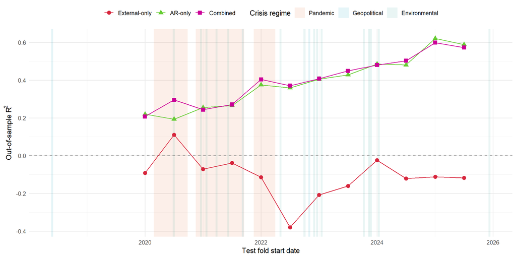

```r
all_m <- rbind(m_ar, m_ext, m_comb)
all_m$model <- factor(all_m$model, levels = c("External-only", "AR-only", "Combined"))

# Crisis bands are derived from `crisis_calendar` via geom_rect + a data frame, NOT from
# hard-coded annotate() literals. Short events are widened symmetrically to MIN_BAND_DAYS
# purely so that a two-day event is not rendered as an invisible one-pixel line; the padding
# is cosmetic, explicit, and applied to the canonical dates rather than replacing them.
MIN_BAND_DAYS <- 14

bands       <- crisis_calendar
bands$width <- as.integer(bands$end - bands$start) + 1L
bands$pad   <- pmax(0, (MIN_BAND_DAYS - bands$width) %/% 2)
bands$xmin  <- bands$start - bands$pad
bands$xmax  <- bands$end   + bands$pad
bands$type  <- factor(c(pandemic     = "Pandemic",
                        geopolitical = "Geopolitical",
                        climate      = "Environmental")[bands$type],
                      levels = c("Pandemic", "Geopolitical", "Environmental"))

band_cols <- c(Pandemic = "#E65F2B", Geopolitical = "#0099B8", Environmental = "#2A9D8F")

p_r2 <- ggplot() +
  geom_rect(data = bands,
            aes(xmin = xmin, xmax = xmax, ymin = -Inf, ymax = Inf, fill = type),
            alpha = 0.10, inherit.aes = FALSE) +
  scale_fill_manual(values = band_cols, name = "Crisis regime") +
  geom_hline(yintercept = 0, linetype = "dashed", colour = "grey50") +
  geom_line(data = all_m, aes(test_start, r2, colour = model), linewidth = 0.6) +
  geom_point(data = all_m, aes(test_start, r2, colour = model, shape = model), size = 2.6) +
  scale_colour_manual(values = c("External-only" = "#D7263D",
                                 "AR-only"       = "#66CC33",
                                 "Combined"      = "#CC0099"), name = NULL) +
  scale_shape_discrete(name = NULL) +
  labs(x = "Test fold start date", y = expression("Out-of-sample R"^2)) +
  theme_minimal(base_size = 11) +
  theme(legend.position = "top")

p_r2
```

```r
ggsave(file.path(AR_DIR, "comparison_r2_by_fold.png"), p_r2,
       width = 11, height = 5.5, dpi = 150)
ggsave(file.path(OUT_DIR, "PDFs", "Figure_4.pdf"), p_r2, width = 14, height = 5.5)
```

## 4.9 Incremental value of external features

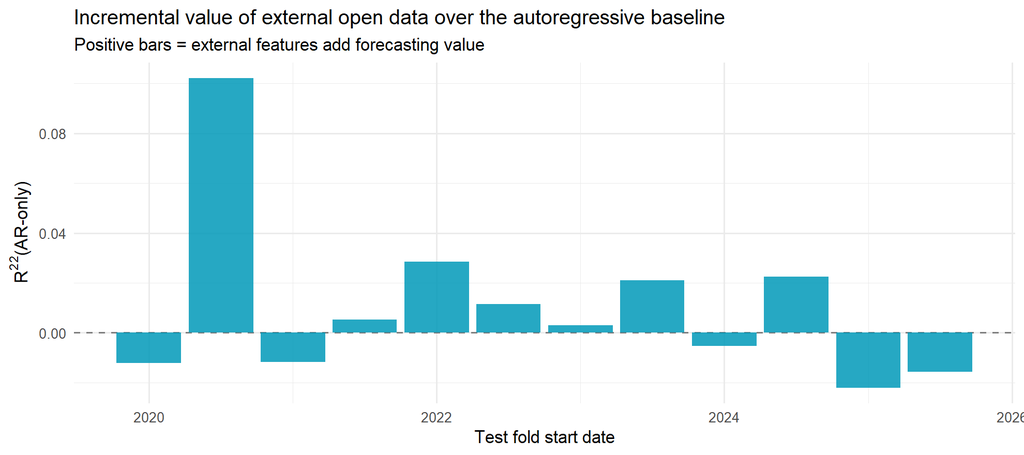

```r
inc <- data.frame(test_start = m_comb$test_start, incremental = m_comb$r2 - m_ar$r2)
p_inc <- ggplot(inc, aes(test_start, incremental)) +
  geom_hline(yintercept = 0, linetype = "dashed", colour = "grey50") +
  geom_col(fill = "#0099B8", alpha = 0.85) +
  labs(x = "Test fold start date",
       y = expression("R"^2 * "(Combined) − R"^2 * "(AR-only)"),
       title = "Incremental value of external open data over the autoregressive baseline",
       subtitle = "Positive bars = external features add forecasting value") +
  theme_minimal(base_size = 11)
p_inc
```

```r
ggsave(file.path(AR_DIR, "comparison_incremental_value.png"), p_inc,
       width = 11, height = 4.5, dpi = 150)
```

## 4.10 Sensitivity: hyperparameter transfer

A reviewer could object that the hyperparameters were tuned by 5-fold `xgb.cv` on the *whole* panel, so a trace of post-cutoff information reaches the models through the choice of `max_depth` and friends. We therefore re-tune on **fold 1’s training window only** (2018–2019) and re-run all three specifications. If the ranking survives, the finding is not an artefact of the tuning protocol.

```r
SENS <- file.path(OUT_DIR, "hyperparam_sensitivity.csv")

if (!file.exists(SENS) && RUN_HEAVY) {
  X_ext <- as.matrix(df_model[, external_features, drop = FALSE])
  storage.mode(X_ext) <- "double"

  ff1 <- build_fold_features(folds$train_end[1])
  ti  <- which(dates_model <= folds$train_end[1] & !is.na(ff1$y))
  L1  <- do.call(cbind, ff1$lags)

  grid <- expand.grid(max_depth = c(4, 5, 6), eta = c(0.05, 0.10),
                      subsample = c(0.7, 0.8), colsample_bytree = c(0.7, 0.8),
                      min_child_weight = c(5, 10), gamma = c(0, 0.1),
                      KEEP.OUT.ATTRS = FALSE, stringsAsFactors = FALSE)
  dtune <- xgb.DMatrix(cbind(X_ext[ti, , drop = FALSE], L1[ti, , drop = FALSE]),
                       label = ff1$y[ti])

  set.seed(42); best <- list(rmse = Inf, row = NULL)
  for (g in seq_len(nrow(grid))) {
    p  <- c(list(objective = "reg:squarederror", eval_metric = "rmse",
                 lambda = 2.0, alpha = 0.1, nthread = 4), as.list(grid[g, ]))
    cv <- xgb.cv(params = p, data = dtune, nrounds = 1000, nfold = 5,
                 early_stopping_rounds = 30, verbose = 0)
    r  <- min(cv$evaluation_log$test_rmse_mean)
    if (r < best$rmse) best <- list(rmse = r, row = grid[g, ])
  }
  sp <- c(list(objective = "reg:squarederror", eval_metric = "rmse",
               lambda = 2.0, alpha = 0.1, nthread = 4), as.list(best$row))

  specs <- c("External-only", "AR-only", "Combined")
  r2m   <- matrix(NA_real_, nrow(folds), 3, dimnames = list(NULL, specs))

  for (i in seq_len(nrow(folds))) {
    fo <- folds[i, ]
    trf <- which(dates_model <= fo$train_end)
    te  <- which(dates_model >= fo$test_start & dates_model <= fo$test_end)
    if (!length(te)) next
    vc <- fo$train_end - VAL_WINDOW_DAYS
    tr <- trf[dates_model[trf] <= vc]; va <- trf[dates_model[trf] > vc]

    ff <- build_fold_features(fo$train_end); y <- ff$y
    L  <- do.call(cbind, ff$lags)
    feat <- list(`External-only` = X_ext, `AR-only` = L, `Combined` = cbind(X_ext, L))

    for (s in specs) {
      Xs  <- feat[[s]]
      mdl <- xgb.train(params = sp, data = xgb.DMatrix(Xs[tr, , drop = FALSE], label = y[tr]),
                       nrounds = 2000,
                       evals = list(v = xgb.DMatrix(Xs[va, , drop = FALSE], label = y[va])),
                       early_stopping_rounds = 50, verbose = 0)
      bi <- as.integer(mdl$best_iteration)
      if (!length(bi) || is.na(bi) || bi < 1L) bi <- as.integer(mdl$niter %||% 2000L)
      sl <- tryCatch(xgb.slice.Booster(mdl, start = 1L, end = bi), error = function(e) NULL)
      yp <- if (!is.null(sl)) predict(sl, Xs[te, , drop = FALSE]) else predict(mdl, Xs[te, , drop = FALSE])
      yt <- y[te]
      r2m[i, s] <- 1 - sum((yt - yp)^2) / sum((yt - mean(yt))^2)
    }
  }

  main <- setNames(summary_df$mean_r2, summary_df$model)
  tab  <- data.frame(model = specs,
                     sens_mean_R2     = round(colMeans(r2m, na.rm = TRUE), 3),
                     sens_negR2_folds = colSums(r2m < 0, na.rm = TRUE),
                     main_run_R2      = round(as.numeric(main[specs]), 3))
  tab$delta_R2 <- round(tab$sens_mean_R2 - tab$main_run_R2, 3)
  write.csv(tab, SENS, row.names = FALSE)
}

if (file.exists(SENS)) {
  knitr::kable(read.csv(SENS), row.names = FALSE,
               caption = "Hyperparameter-transfer sensitivity: tuning restricted to fold 1's training window")
}
```

Hyperparameter-transfer sensitivity: tuning restricted to fold 1’s training window

[output not shown]

The ordering is robust if *External-only* remains far below *AR-only* ≈ *Combined*, and if *External-only*’s mean $R^2$ stays at or below zero.

# 5 Part 4 — Early-warning evaluation

Regression $R^2$ is not what a supply-chain operator cares about. The operational question is binary and asymmetric: **will this city cross 2σ, and will I know early enough to act?**

We therefore threshold the *observed* PBB-Score at 2σ to define panic days, and use each model’s *predicted* PBB-Score as a continuous alarm score. Two consequences follow from the class imbalance (roughly 4% positives):

- **AUC-PR is the headline, not AUC-ROC.** With rare positives, ROC curves are optimistic because the false-positive rate is diluted by a huge negative class (Saito & Rehmsmeier, 2015). We report AUC-PR as a *lift over the base rate*, which is the honest scale.
- **The alarm threshold τ is selected on validation data, never on test.** For each fold we sweep τ on the internal validation split, take the F1-maximising value, and use the median across folds as the operating point.

```r
LEAD_LOOKBACK_DAYS <- 14
CW_DIR <- file.path(OUT_DIR, "classification_three_way")

compute_at_threshold <- function(y_true, y_pred, tau) {
  alarm <- as.integer(y_pred >= tau)
  tp <- sum(alarm == 1 & y_true == 1); fp <- sum(alarm == 1 & y_true == 0)
  fn <- sum(alarm == 0 & y_true == 1); tn <- sum(alarm == 0 & y_true == 0)
  prec <- if ((tp + fp) > 0) tp / (tp + fp) else NA_real_
  rec  <- if ((tp + fn) > 0) tp / (tp + fn) else NA_real_
  f1   <- if (!is.na(prec) && !is.na(rec) && (prec + rec) > 0) 2 * prec * rec / (prec + rec) else NA_real_
  data.frame(threshold = tau, alarm_rate = mean(alarm),
             tp = tp, fp = fp, fn = fn, tn = tn, precision = prec, recall = rec, f1 = f1)
}
```

## 5.1 Lead time, measured against the right counterfactual

A naive lead-time statistic (“the alarm fired 3 days before 62% of episodes”) is close to meaningless on its own: an alarm that is *always on* would detect 100% of episodes. The only informative quantity is detection relative to a **non-panic baseline** — how often the alarm also fires in a randomly chosen 14-day window that contains *no* panic. The difference between the two is the lift.

```r
lead_times_with_baseline <- function(pred_df, tau, lookback = LEAD_LOOKBACK_DAYS) {
  pred_df <- pred_df %>% arrange(city, date)
  pred_df$alarm <- as.integer(pred_df$y_pred >= tau)

  eps <- list(); base <- list()
  for (ct in unique(pred_df$city)) {
    cd <- pred_df %>% filter(city == ct) %>% arrange(date)
    if (nrow(cd) < lookback + 1) next

    rise <- which(cd$is_panic == 1 & (c(0, head(cd$is_panic, -1)) == 0))
    for (i in rise) {
      ep  <- cd$date[i]
      win <- cd %>% filter(date >= ep - lookback, date < ep)
      if (!nrow(win)) next
      crossed  <- which(win$alarm == 1)
      detected <- length(crossed) > 0
      eps[[length(eps) + 1]] <- data.frame(
        city = ct, episode_start = ep, detected = detected,
        lead_time_days = if (detected) as.numeric(ep - win$date[min(crossed)]) else NA_real_)
    }

    # Matched non-panic reference windows (3 per episode)
    non_panic <- which(cd$is_panic == 0)
    n_ref <- length(rise) * 3
    if (length(non_panic) > n_ref && length(rise) > 0) {
      set.seed(42)
      for (j in sample(non_panic, n_ref)) {
        if (j <= lookback) next
        ref <- cd$date[j]
        win <- cd %>% filter(date >= ref - lookback, date < ref)
        if (sum(win$is_panic) > 0) next          # window must be genuinely calm
        base[[length(base) + 1]] <- data.frame(city = ct, ref_date = ref,
                                               any_alarm = sum(win$alarm) > 0)
      }
    }
  }
  list(episodes = if (length(eps))  do.call(rbind, eps)  else data.frame(),
       baseline = if (length(base)) do.call(rbind, base) else data.frame())
}
```

## 5.2 Analysing all three models

```r
val_tau <- function(fr) {
  vp <- do.call(rbind, lapply(fr, function(f) { v <- f$val_predictions; v$fold_id <- f$fold_id; v }))
  vp$is_panic <- as.integer(vp$y_true >= PANIC_THRESHOLD)
  g  <- seq(0.1, 3.0, by = 0.05)
  ft <- sapply(split(vp, vp$fold_id), function(d) {
    if (sum(d$is_panic) == 0) return(NA_real_)
    f1v <- sapply(g, function(t) { f1 <- compute_at_threshold(d$is_panic, d$y_pred, t)$f1
                                   if (is.na(f1)) 0 else f1 })
    g[which.max(f1v)]
  })
  stats::median(ft, na.rm = TRUE)
}

COMMON_TAU <- val_tau(res_comb)
cat(sprintf("Validation-selected common operating threshold: tau = %.2f\n", COMMON_TAU))
```

```
## Validation-selected common operating threshold: tau = 0.78
```

```r
analyze_model <- function(fr, nm) {
  preds <- do.call(rbind, lapply(fr, function(f) cbind(fold_id = f$fold_id, f$predictions)))
  vp    <- do.call(rbind, lapply(fr, function(f) { v <- f$val_predictions; v$fold_id <- f$fold_id; v }))
  preds$is_panic <- as.integer(preds$y_true >= PANIC_THRESHOLD)
  base_rate <- mean(preds$is_panic)

  pr  <- PRROC::pr.curve(preds$y_pred[preds$is_panic == 1],
                         preds$y_pred[preds$is_panic == 0], curve = TRUE)
  roc <- PRROC::roc.curve(preds$y_pred[preds$is_panic == 1],
                          preds$y_pred[preds$is_panic == 0], curve = TRUE)

  per_fold <- do.call(rbind, lapply(split(preds, preds$fold_id), function(d) {
    if (sum(d$is_panic) == 0) return(data.frame(fold_id = d$fold_id[1], n_pos = 0,
                                                auc_pr = NA, auc_roc = NA,
                                                base_rate = 0, model = nm))
    data.frame(fold_id = d$fold_id[1], n_pos = sum(d$is_panic),
               auc_pr  = PRROC::pr.curve(d$y_pred[d$is_panic == 1],
                                         d$y_pred[d$is_panic == 0])$auc.integral,
               auc_roc = PRROC::roc.curve(d$y_pred[d$is_panic == 1],
                                          d$y_pred[d$is_panic == 0])$auc,
               base_rate = mean(d$is_panic), model = nm)
  }))

  sweep_grid    <- seq(0.1, 3.0, by = 0.05)
  sweep_metrics <- do.call(rbind, lapply(sweep_grid, function(t)
    compute_at_threshold(preds$is_panic, preds$y_pred, t)))
  sweep_metrics$model <- nm

  # Operating point: each model's OWN validation-selected F1-optimal threshold,
  # taken as the median of per-fold optima on the internal validation splits. This
  # is exactly what the production script uses for `lead_own` / Figure 5c: because
  # `val_predictions` is always supplied in the three-way comparison, the original's
  # apparent "pooled-test F1-optimal" branch is never reached. No test data touches
  # threshold selection.
  vp$is_panic <- as.integer(vp$y_true >= PANIC_THRESHOLD)
  fold_tau <- sapply(split(vp, vp$fold_id), function(d) {
    if (sum(d$is_panic) == 0) return(NA_real_)
    f1v <- sapply(sweep_grid, function(t) { f1 <- compute_at_threshold(d$is_panic, d$y_pred, t)$f1
                                            if (is.na(f1)) 0 else f1 })
    sweep_grid[which.max(f1v)]
  })
  opt_threshold <- stats::median(fold_tau, na.rm = TRUE)

  lead <- lead_times_with_baseline(preds, opt_threshold)
  det  <- if (nrow(lead$episodes)) mean(lead$episodes$detected)  else NA_real_
  bl   <- if (nrow(lead$baseline)) mean(lead$baseline$any_alarm) else NA_real_

  list(model = nm, predictions = preds, base_rate = base_rate,
       pr = pr, roc = roc, per_fold = per_fold, sweep = sweep_metrics,
       tau = opt_threshold, tau_val = opt_threshold,
       metrics_opt = compute_at_threshold(preds$is_panic, preds$y_pred, opt_threshold),
       lead = lead, detection = det, baseline = bl)
}

results <- list(
  `AR-only`       = analyze_model(res_ar,   "AR-only"),
  `External-only` = analyze_model(res_ext,  "External-only"),
  `Combined`      = analyze_model(res_comb, "Combined")
)
```

```r
R2_PRIOR <- setNames(summary_df$mean_r2, summary_df$model)

ews <- do.call(rbind, lapply(results, function(r) data.frame(
  model            = r$model,
  R2_regression    = unname(R2_PRIOR[r$model]),
  base_rate        = r$base_rate,
  AUC_PR           = r$pr$auc.integral,
  AUC_PR_lift      = r$pr$auc.integral / r$base_rate,
  AUC_ROC          = r$roc$auc,
  tau_own          = r$tau,       # own F1-optimal on pooled test (used for detection panel)
  tau_val          = r$tau_val,   # validation-selected operating point (leakage-free)
  F1_at_tau        = r$metrics_opt$f1,
  precision_at_tau = r$metrics_opt$precision,
  recall_at_tau    = r$metrics_opt$recall,
  detection_rate   = r$detection,
  nonpanic_baseline= r$baseline,
  detection_lift   = r$detection - r$baseline,
  stringsAsFactors = FALSE)))
rownames(ews) <- NULL

write.csv(ews, file.path(CW_DIR, "comparison_summary.csv"), row.names = FALSE)
write.csv(do.call(rbind, lapply(results, function(r) r$per_fold)),
          file.path(CW_DIR, "metrics_per_fold.csv"), row.names = FALSE)

knitr::kable(ews[, c("model", "R2_regression", "AUC_PR", "AUC_PR_lift", "AUC_ROC",
                     "tau_own", "F1_at_tau", "detection_rate", "nonpanic_baseline",
                     "detection_lift")],
             digits = 3, row.names = FALSE,
             caption = "Headline early-warning comparison (canonical run output)")
```

Headline early-warning comparison (canonical run output)

| model | R2_regression | AUC_PR | AUC_PR_lift | AUC_ROC | tau_own | F1_at_tau | detection_rate | nonpanic_baseline | detection_lift |
| --- | --- | --- | --- | --- | --- | --- | --- | --- | --- |
| AR-only | 0.390 | 0.089 | 4.035 | 0.735 | 0.850 | 0.157 | 0.380 | 0.117 | 0.263 |
| External-only | -0.111 | 0.042 | 1.900 | 0.515 | 0.150 | 0.074 | 0.377 | 0.432 | -0.055 |
| Combined | 0.401 | 0.101 | 4.608 | 0.744 | 0.775 | 0.175 | 0.429 | 0.161 | 0.268 |

```
## Incremental value of external features, classification side (Combined - AR-only):
```

```
##   Delta AUC-PR        : +0.013
```

```
##   Delta AUC-ROC       : +0.008
```

```
##   Delta F1 (at tau)   : +0.018
```

```
##   Delta detection lift: +0.5 pp
```

## 5.3 Figures: PR curves, ROC curves, threshold sweep, lead time

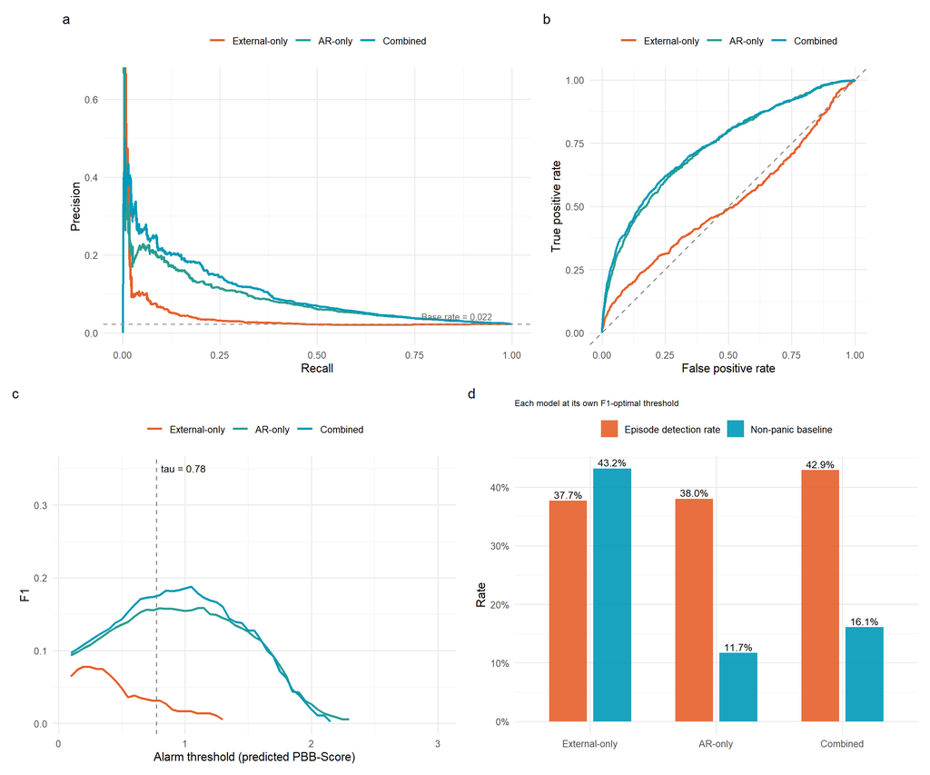

```r
MODEL_COLS <- c("AR-only" = "#2A9D8F", "External-only" = "#E65F2B", "Combined" = "#0099B8")
fix_order  <- function(d) { d$model <- factor(d$model,
                              levels = c("External-only", "AR-only", "Combined")); d }

pr_df  <- do.call(rbind, lapply(results, function(r)
  data.frame(model = r$model, recall = r$pr$curve[, 1], precision = r$pr$curve[, 2])))
roc_df <- do.call(rbind, lapply(results, function(r)
  data.frame(model = r$model, fpr = r$roc$curve[, 1], tpr = r$roc$curve[, 2])))
sweep_df <- do.call(rbind, lapply(results, function(r) r$sweep))
lead_df  <- do.call(rbind, lapply(results, function(r) data.frame(
  model  = r$model,
  metric = c("Episode detection rate", "Non-panic baseline"),
  value  = c(r$detection, r$baseline))))

p_pr <- ggplot(fix_order(pr_df), aes(recall, precision, colour = model)) +
  geom_line(linewidth = 1) +
  geom_hline(yintercept = results[[1]]$base_rate, linetype = "dashed", colour = "grey60") +
  annotate("text", x = 0.95, y = results[[1]]$base_rate + 0.02, hjust = 1, size = 3,
           colour = "grey40", label = sprintf("Base rate = %.3f", results[[1]]$base_rate)) +
  scale_colour_manual(values = MODEL_COLS) +
  coord_equal(xlim = c(0, 1), ylim = c(0, 0.65)) +
  labs(x = "Recall", y = "Precision", colour = NULL, tag = "a") +
  theme_minimal(base_size = 11) + theme(legend.position = "top")

p_roc <- ggplot(fix_order(roc_df), aes(fpr, tpr, colour = model)) +
  geom_line(linewidth = 1) +
  geom_abline(slope = 1, intercept = 0, linetype = "dashed", colour = "grey50") +
  scale_colour_manual(values = MODEL_COLS) + coord_equal() +
  labs(x = "False positive rate", y = "True positive rate", colour = NULL, tag = "b") +
  theme_minimal(base_size = 11) + theme(legend.position = "top")

p_sweep <- ggplot(fix_order(sweep_df), aes(threshold, f1, colour = model)) +
  geom_line(linewidth = 1) +
  geom_vline(xintercept = COMMON_TAU, linetype = "dashed", colour = "grey50") +
  annotate("text", x = COMMON_TAU, y = 0.35, hjust = -0.1, size = 3.2,
           label = sprintf("tau = %.2f", COMMON_TAU)) +
  scale_colour_manual(values = MODEL_COLS) +
  labs(x = "Alarm threshold (predicted PBB-Score)", y = "F1", colour = NULL, tag = "c") +
  theme_minimal(base_size = 11) + theme(legend.position = "top")

p_lead <- ggplot(fix_order(lead_df), aes(model, value, fill = metric)) +
  geom_col(position = position_dodge(width = 0.7), width = 0.6, alpha = 0.9) +
  geom_text(aes(label = sprintf("%.1f%%", 100 * value)),
            position = position_dodge(width = 0.7), vjust = -0.3, size = 3.2) +
  scale_fill_manual(values = c("Episode detection rate" = "#E65F2B",
                               "Non-panic baseline"     = "#0099B8")) +
  scale_y_continuous(labels = scales::percent_format()) +
  labs(x = NULL, y = "Rate", fill = NULL, tag = "d",
       subtitle = "Each model at its own F1-optimal threshold") +
  theme_minimal(base_size = 11) +
  theme(legend.position = "top", plot.subtitle = element_text(size = 8))

(p_pr + p_roc) / (p_sweep + p_lead)
```

# 6 Part 5 — Model interpretation with SHAP

SHAP values (Lundberg & Lee, 2017; Shapley, 1953) tell us *which* features the gradient-boosted model relies on. Two caveats, stated up front:

1. The SHAP model is fitted on a **random 80/20 split**, deliberately — the same split whose forecasting numbers Part 3 rejects. That is defensible only because we are asking an *attribution* question (“what does the model use?”), not a *performance* question. Its $R^2$ must not be reported as evidence of predictive skill, and it is not.
2. SHAP importance is a property of a fitted model, not of nature. It says which signals this model exploited, not which signals cause panic buying. The causal-flavoured questions are handled in Part 6 by Local Projections.

```r
SHAP_DIR <- file.path(OUT_DIR, "Shap")

df_s <- read.csv2(PANEL_CSV, fileEncoding = "UTF-8") %>%
  dplyr::select(-any_of(c(cols_to_drop, "date", "city")))
pv <- grep("^S_pandemic", names(df_s), value = TRUE)
df_s[, pv] <- lapply(df_s[, pv], function(x) replace(x, is.na(x), 0))
cc <- names(df_s)[sapply(df_s, is.character)]
for (col in cc) df_s[[col]] <- as.numeric(as.factor(df_s[[col]]))

df_s <- df_s %>% filter(!is.na(.data[[TARGET]]))
Xs   <- df_s %>% dplyr::select(-all_of(TARGET)) %>% mutate(across(everything(), as.numeric))
ys   <- df_s[[TARGET]]

set.seed(42)
tr_i <- caret::createDataPartition(ys, p = 0.8, list = FALSE)
dtr  <- xgb.DMatrix(as.matrix(Xs[tr_i, ]),  label = ys[tr_i])
dte  <- xgb.DMatrix(as.matrix(Xs[-tr_i, ]), label = ys[-tr_i])

N_ROUNDS <- if (!is.null(best_row$nrounds) && !is.na(best_row$nrounds)) {
  as.integer(best_row$nrounds)
} else 500L

shap_model <- xgb.train(params = base_params, data = dtr,
                        nrounds = N_ROUNDS, verbose = 0)

r2_random <- 1 - sum((ys[-tr_i] - predict(shap_model, dte))^2) /
                 sum((ys[-tr_i] - mean(ys[-tr_i]))^2)
cat(sprintf("Random-split test R2 = %.3f  <-- interpolation, NOT forecasting skill.\n", r2_random))
```

```
## Random-split test R2 = 0.358  <-- interpolation, NOT forecasting skill.
```

```r
cat(sprintf("Compare with the temporal-CV External-only R2 = %+.3f.\n",
            summary_df$mean_r2[summary_df$model == "External-only"]))
```

```
## Compare with the temporal-CV External-only R2 = -0.111.
```

That single contrast is, in one line, the paper’s methodological point: the same feature set, the same model class, the same data — and a difference of roughly 0.47 in $R^2$ that comes entirely from how the data were split.

```r
shap_rds <- file.path(SHAP_DIR, "shap_matrix.rds")
xts_rds  <- file.path(SHAP_DIR, "X_test_sample.rds")

if (!file.exists(shap_rds)) {
  if (!RUN_HEAVY) stop("SHAP cache missing and run_heavy = FALSE.")
  unified <- treeshap::xgboost.unify(shap_model, as.matrix(Xs[tr_i, ]))
  X_te    <- Xs[-tr_i, ]
  set.seed(42)
  X_te_s  <- if (nrow(X_te) > 1000) X_te[sample(nrow(X_te), 1000), ] else X_te
  shap_matrix <- treeshap::treeshap(unified, as.matrix(X_te_s))$shaps
  saveRDS(X_te_s, xts_rds); saveRDS(shap_matrix, shap_rds)
} else {
  X_te_s      <- readRDS(xts_rds)
  shap_matrix <- readRDS(shap_rds)
}

shap_importance <- data.frame(Feature    = colnames(X_te_s),
                              Importance = colMeans(abs(shap_matrix))) %>%
  arrange(desc(Importance))
write.csv(shap_importance, file.path(SHAP_DIR, "shap_feature_importance.csv"), row.names = FALSE)

knitr::kable(head(shap_importance, 15), digits = 4, row.names = FALSE,
             caption = "Top 15 features by mean |SHAP|")
```

Top 15 features by mean |SHAP|

| Feature | Importance |
| --- | --- |
| S_pandemic_Gtrends | 0.1304 |
| S_pandemic_cumuldeaths_log | 0.0794 |
| O_supermarket_Gtrends | 0.0762 |
| S_pandemic_cumulcases_log | 0.0675 |
| S_wind_gust_max | 0.0637 |
| S_health_Gtrends | 0.0633 |
| O_minimarket_Gtrends | 0.0608 |
| S_precip_acc_3d | 0.0526 |
| O_psych_fear_Gtrends | 0.0511 |
| O_gov_policy_Gtrends | 0.0500 |
| O_inflation_Gtrends | 0.0496 |
| S_strike_Gtrends | 0.0369 |
| S_climate_Gtrends | 0.0330 |
| O_mobil_dist_0 | 0.0265 |
| S_cyclone_Gtrends | 0.0219 |

## 6.1 Stimulus vs. Organism, and the S-O-R sub-domains

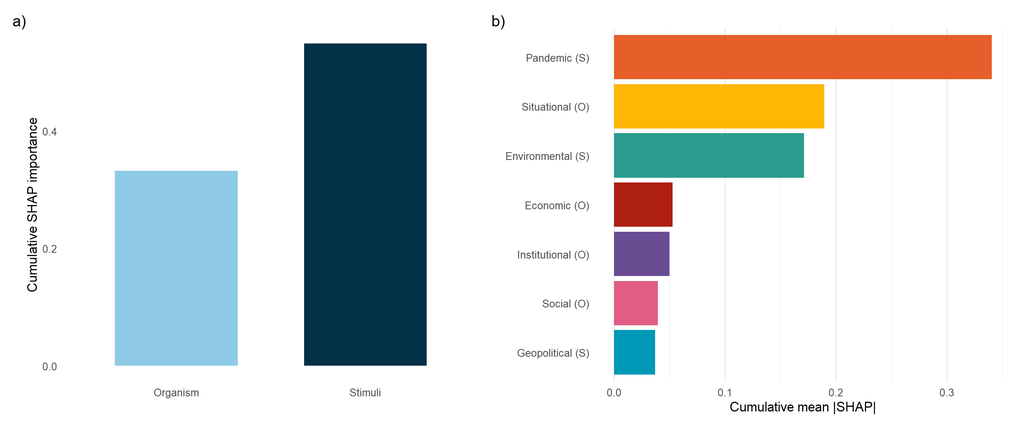

```r
stimuli_f  <- grep("^S_", colnames(X_te_s), value = TRUE)
organism_f <- grep("^O_", colnames(X_te_s), value = TRUE)

imp <- function(v) sum(shap_importance$Importance[shap_importance$Feature %in% v])

cat_so <- data.frame(Category = c("Stimuli", "Organism"),
                     Total_Importance = c(imp(stimuli_f), imp(organism_f)))

domains <- list(
  "Pandemic (S)"      = c("S_pandemic_Gtrends", "S_pandemic_cumulcases_log",
                          "S_pandemic_cumuldeaths_log", "S_health_Gtrends"),
  "Environmental (S)" = c("S_wind_gust_max", "S_precip_acc_3d",
                          "S_climate_Gtrends", "S_cyclone_Gtrends"),
  "Geopolitical (S)"  = c("S_strike_Gtrends", "S_strike_event"),
  "Institutional (O)" = "O_gov_policy_Gtrends",
  "Social (O)"        = c("O_mobil_dist_0", "O_mobil_dist_0_10km",
                          "O_mobil_dist_10_100km", "O_mobil_dist_100km_plus", "O_news_count"),
  "Situational (O)"   = c("O_psych_fear_Gtrends", "O_supermarket_Gtrends",
                          "O_minimarket_Gtrends", "O_rationing_Gtrends"),
  "Economic (O)"      = c("O_inflation_Gtrends", "O_basicfoodbasket_Gtrends")
)
cat_sub <- data.frame(Category   = names(domains),
                      Importance = sapply(domains, imp)) %>% arrange(desc(Importance))

domain_cols <- c("Environmental (S)" = "#2A9D8F", "Geopolitical (S)" = "#0099B8",
                 "Pandemic (S)" = "#E65F2B", "Situational (O)" = "#FFB703",
                 "Social (O)" = "#E25C84", "Institutional (O)" = "#6A4C93",
                 "Economic (O)" = "#AE2012")

pa <- ggplot(cat_so, aes(Category, Total_Importance, fill = Category)) +
  geom_col(width = 0.65, show.legend = FALSE) +
  scale_fill_manual(values = c("Stimuli" = "#023047", "Organism" = "#8ECAE6")) +
  labs(tag = "a)", x = NULL, y = "Cumulative SHAP importance") +
  theme_minimal(base_size = 11) + theme(panel.grid = element_blank())

pb <- ggplot(cat_sub, aes(Importance, reorder(Category, Importance), fill = Category)) +
  geom_col(show.legend = FALSE) +
  scale_fill_manual(values = domain_cols) +
  labs(tag = "b)", y = NULL, x = "Cumulative mean |SHAP|") +
  theme_minimal(base_size = 11) +
  theme(panel.grid.major.y = element_blank(), panel.grid.minor.y = element_blank())

combined_fig <- pa + pb
combined_fig
```

```r
ggsave(file.path(SHAP_DIR, "combined_figure2.png"), combined_fig,
       width = 12, height = 5, dpi = 300)
ggsave(file.path(OUT_DIR, "PDFs", "Figure_6.pdf"), combined_fig, width = 12, height = 5)
```

## 6.2 SHAP beeswarm (feature impact)

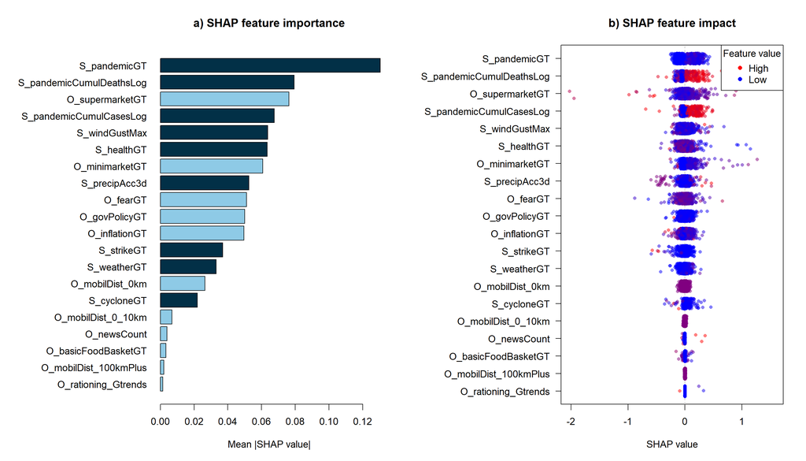

```r
top_n  <- 20
top_f  <- head(shap_importance, top_n)

label_dict <- c(
  S_pandemic_Gtrends = "S_pandemicGT", O_supermarket_Gtrends = "O_supermarketGT",
  S_pandemic_cumuldeaths_log = "S_pandemicCumulDeathsLog", S_wind_gust_max = "S_windGustMax",
  O_minimarket_Gtrends = "O_minimarketGT", S_health_Gtrends = "S_healthGT",
  S_precip_acc_3d = "S_precipAcc3d", O_gov_policy_Gtrends = "O_govPolicyGT",
  S_pandemic_cumulcases_log = "S_pandemicCumulCasesLog", O_psych_fear_Gtrends = "O_fearGT",
  O_inflation_Gtrends = "O_inflationGT", O_mobil_dist_10_100km = "O_mobilDist_10_100km",
  O_mobil_dist_0_10km = "O_mobilDist_0_10km", O_mobil_dist_0 = "O_mobilDist_0km",
  O_mobil_dist_100km_plus = "O_mobilDist_100kmPlus", S_strike_Gtrends = "S_strikeGT",
  S_climate_Gtrends = "S_weatherGT", S_cyclone_Gtrends = "S_cycloneGT",
  O_news_count = "O_newsCount", O_basicfoodbasket_Gtrends = "O_basicFoodBasketGT"
)
relabel <- function(x) { y <- label_dict[x]; y[is.na(y)] <- x[is.na(y)]; unname(y) }

shap_sub <- shap_matrix[, top_f$Feature, drop = FALSE]
feat_val <- as.matrix(X_te_s[, top_f$Feature, drop = FALSE])

op <- par(no.readonly = TRUE)
par(mfrow = c(1, 2), mar = c(5, 14, 4, 2))

rev_f <- rev(top_f$Feature)
barplot(rev(top_f$Importance), names.arg = relabel(rev_f), horiz = TRUE, las = 1,
        col = ifelse(startsWith(rev_f, "O_"), "#8ECAE6", "#023047"),
        main = "a) SHAP feature importance", xlab = "Mean |SHAP value|")

x_rng <- range(shap_sub, na.rm = TRUE)
plot(NULL, xlim = c(x_rng[1], x_rng[2] * 1.25), ylim = c(1, top_n),
     xlab = "SHAP value", ylab = "", main = "b) SHAP feature impact", yaxt = "n")
axis(2, at = 1:top_n, labels = relabel(rev_f), las = 1)
abline(v = 0, col = "grey", lty = 2)
for (i in 1:top_n) {
  k  <- top_n - i + 1
  sv <- shap_sub[, k]; fv <- feat_val[, k]
  nz <- (fv - min(fv, na.rm = TRUE)) / (max(fv, na.rm = TRUE) - min(fv, na.rm = TRUE))
  nz[is.na(nz)] <- 0.5
  points(sv, i + runif(length(sv), -0.3, 0.3), pch = 16, cex = 0.8,
         col = rgb(nz, 0, 1 - nz, alpha = 0.5))
}
legend("topright", legend = c("High", "Low"), col = c("red", "blue"), pch = 16,
       title = "Feature value", bg = "white")
```

```r
par(op)
```

# 7 Part 6 — Local Projections: dynamic responses

SHAP describes a *predictive* association at a point in time. The theoretically interesting question is **dynamic**: when a stimulus arrives, how does the PBB-Score evolve over the following two weeks, and does that response differ across crisis regimes?

We estimate Jordà (2005) Local Projections, horizon by horizon:

$$\text{PBB}_{c,t+h} \;=\; \alpha_c \;+\; \beta_h\, x_{c,t} \;+\;
\sum_{r} \delta_h^{(r)}\, \bigl(x_{c,t} \times C_t^{(r)}\bigr) \;+\;
\sum_{r} \gamma_h^{(r)} C_t^{(r)} \;+\;
\sum_{k \in \{1,7,14,28\}} \rho_{h,k}\,\text{PBB}_{c,t-k} \;+\;
\varepsilon_{c,t+h}$$

Three specification choices matter:

- **A single joint specification with regime interactions**, rather than separate regressions per regime. Splitting the sample would throw away the calm-period information that identifies $\beta_h$ and would make the regime contrasts untestable.
- **Two-way clustered standard errors on city *and* date.** Clustering on city alone would ignore the fact that all 15 municipalities are hit by the same national shocks on the same day; this is the cross-sectional dependence that Plagborg-Møller & Wolf (2021) warn about in panel LPs.
- **Regime totals use the full linear-combination variance**, $\mathrm{Var}(\hat\beta_h + \hat\delta_h) = \mathrm{Var}(\hat\beta_h) + \mathrm{Var}(\hat\delta_h) + 2\,\mathrm{Cov}(\hat\beta_h, \hat\delta_h)$. Omitting the covariance term (a common error) understates or overstates the CI depending on its sign.

```r
LP_DIR   <- file.path(OUT_DIR, "local_projections")
HORIZONS <- 0:14

# --- Regime calendar -----------------------------------------------------------------
# Set to character(0) to use the full canonical calendar. Left as-is, it reproduces the
# regime definitions actually used in Temporal_CV_v9.R for the LP and episode blocks.
V9_CLIMATE_OMISSIONS <- c("sc_cyclone_2022", "sc_floods_2023")

regime_calendar <- crisis_calendar[!(crisis_calendar$event %in% V9_CLIMATE_OMISSIONS), ]

cat(sprintf("Regime calendar: %d of %d canonical events (%d climate window(s) omitted to match v9)\n",
            nrow(regime_calendar), nrow(crisis_calendar), length(V9_CLIMATE_OMISSIONS)))
```

```
## Regime calendar: 19 of 21 canonical events (2 climate window(s) omitted to match v9)
```

```r
by_type <- split(regime_calendar, regime_calendar$type)

lp_raw <- read.csv2(PANEL_CSV, fileEncoding = "UTF-8")
lp_raw$date <- as.Date(lp_raw$date)

# Defend against read.csv2 re-inferring `logical` for the mostly-NA mobility columns
# (populated only from 2022-12). Without this the Mobilization representative would be
# all-NA and its Local-Projection panel would render empty.
for (cc in grep("mobil", names(lp_raw), value = TRUE, ignore.case = TRUE)) {
  if (is.logical(lp_raw[[cc]])) lp_raw[[cc]] <- as.numeric(lp_raw[[cc]])
  else if (!is.numeric(lp_raw[[cc]]))
    lp_raw[[cc]] <- suppressWarnings(as.numeric(gsub(",", ".", lp_raw[[cc]], fixed = TRUE)))
}

lp_raw$crisis_pandemic <- as.integer(in_calendar(lp_raw$date, by_type$pandemic))
lp_raw$crisis_climate  <- as.integer(in_calendar(lp_raw$date, by_type$climate))
lp_raw$crisis_geopol   <- as.integer(in_calendar(lp_raw$date, by_type$geopolitical))

cat(sprintf("Regime coverage — pandemic %.1f%% | climate %.1f%% | geopolitical %.1f%% | calm %.1f%%\n",
            100 * mean(lp_raw$crisis_pandemic), 100 * mean(lp_raw$crisis_climate),
            100 * mean(lp_raw$crisis_geopol),
            100 * mean(lp_raw$crisis_pandemic + lp_raw$crisis_climate +
                         lp_raw$crisis_geopol == 0)))
```

```
## Regime coverage — pandemic 22.5% | climate 1.5% | geopolitical 0.6% | calm 76.0%
```

## 7.1 Category representatives

```r
CATEGORY_VARS <- list(
  "Trigger (S-pandemic)"      = "S_pandemic_Gtrends",
  "Trigger (S-climate)"       = "S_wind_gust_max",
  "Anticipation (O-news)"     = "O_news_count",
  "Mobilization (O-mobility)" = "O_mobil_dist_0",
  "Realization (price)"       = "O_basicfoodbasket_Gtrends"
)
CATEGORY_VARS <- CATEGORY_VARS[unlist(CATEGORY_VARS) %in% names(lp_raw)]
knitr::kable(data.frame(Construct = names(CATEGORY_VARS),
                        Variable  = unlist(CATEGORY_VARS)),
             row.names = FALSE, caption = "S-O-R category representatives")
```

S-O-R category representatives

| Construct | Variable |
| --- | --- |
| Trigger (S-pandemic) | S_pandemic_Gtrends |
| Trigger (S-climate) | S_wind_gust_max |
| Anticipation (O-news) | O_news_count |
| Mobilization (O-mobility) | O_mobil_dist_0 |
| Realization (price) | O_basicfoodbasket_Gtrends |

```r
panel <- lp_raw %>% filter(!is.na(.data[[TARGET]])) %>% arrange(city, date)

# Standardise each shock so beta_h reads as "PBB-Score change per 1-SD shock"
for (v in unlist(CATEGORY_VARS)) {
  panel[[paste0(v, "_z")]] <- (panel[[v]] - mean(panel[[v]], na.rm = TRUE)) /
                                sd(panel[[v]], na.rm = TRUE)
}

panel <- panel %>% group_by(city) %>%
  mutate(API_lag1  = dplyr::lag(.data[[TARGET]], 1),
         API_lag7  = dplyr::lag(.data[[TARGET]], 7),
         API_lag14 = dplyr::lag(.data[[TARGET]], 14),
         API_lag28 = dplyr::lag(.data[[TARGET]], 28)) %>% ungroup()

for (h in HORIZONS) {
  panel <- panel %>% group_by(city) %>%
    mutate(!!sprintf("API_lead_%d", h) := dplyr::lead(.data[[TARGET]], h)) %>% ungroup()
}
cat(sprintf("LP panel: %s rows x %d columns\n", format(nrow(panel), big.mark = ","), ncol(panel)))
```

```
## LP panel: 43,827 rows x 121 columns
```

```r
# Coverage diagnostic for the sparse mobility representative: if this shows 0
# non-missing rows, the construct genuinely cannot be estimated (data issue) rather
# than being lost to a fragile specification (which the estimator cascade handles).
mob_z <- paste0(CATEGORY_VARS[["Mobilization (O-mobility)"]], "_z")
if (!is.null(mob_z) && mob_z %in% names(panel)) {
  nn <- sum(!is.na(panel[[mob_z]]))
  rng <- range(panel$date[!is.na(panel[[mob_z]])])
  cat(sprintf("Mobility representative (%s): %s non-missing rows, %s to %s\n",
              mob_z, format(nn, big.mark = ","),
              if (is.finite(rng[1])) rng[1] else NA,
              if (is.finite(rng[2])) rng[2] else NA))
}
```

```
## Mobility representative (O_mobil_dist_0_z): 14,756 non-missing rows, 2022-12-02 to 2025-12-31
```

## 7.2 Estimation

```r
CRISIS_DUMMIES <- c("crisis_pandemic", "crisis_climate", "crisis_geopol")
CRISIS_LABELS  <- c(crisis_pandemic = "Pandemic", crisis_climate = "Climate",
                    crisis_geopol   = "Geopolitical")
AR_TERMS <- c("API_lag1", "API_lag7", "API_lag14", "API_lag28")

# Baseline (no regime interaction).
# Sparse constructs (the post-2022 mobility representative in particular) can defeat
# the full two-way-clustered spec: too few date clusters at long horizons, or a
# near-collinear design once 28-day AR lags are added on the short post-2022 sample.
# Rather than let such a construct vanish from the pooled projection — the manuscript
# reports Mobilization in Figure 8 and only omits it from the crisis-interacted
# Figure 9 — we try a cascade of progressively more forgiving specifications and stop
# at the first that returns a finite coefficient. The specification actually used is
# recorded in `se_type` for full transparency.
estimate_lp <- function(panel, shock, h, label) {
  z <- paste0(shock, "_z")

  attempts <- list(
    list(tag = "twoway(city,date)", ar = AR_TERMS,                         cl = ~ city + date, fe = TRUE),
    list(tag = "oneway(city)",      ar = AR_TERMS,                         cl = ~ city,        fe = TRUE),
    list(tag = "oneway(city),AR1-14", ar = c("API_lag1","API_lag7","API_lag14"), cl = ~ city,  fe = TRUE),
    list(tag = "oneway(city),AR1",   ar = "API_lag1",                       cl = ~ city,        fe = TRUE),
    list(tag = "iid,AR1",            ar = "API_lag1",                       cl = NULL,          fe = TRUE),
    list(tag = "noFE,AR1",           ar = "API_lag1",                       cl = NULL,          fe = FALSE)
  )

  for (a in attempts) {
    rhs <- paste(c(z, a$ar), collapse = " + ")
    fml <- as.formula(if (a$fe) sprintf("API_lead_%d ~ %s | city", h, rhs)
                      else       sprintf("API_lead_%d ~ %s",        h, rhs))
    fit <- tryCatch(
      if (is.null(a$cl)) feols(fml, data = panel)
      else               feols(fml, data = panel, cluster = a$cl),
      error = function(e) NULL)
    if (is.null(fit)) next

    ct <- coeftable(fit)
    if (!(z %in% rownames(ct))) next
    est <- ct[z, "Estimate"]; se <- ct[z, "Std. Error"]
    if (!is.finite(est) || !is.finite(se)) next     # dropped-for-collinearity guard

    return(data.frame(category = label, horizon = h, shock = shock,
                      beta = est, se = se, p_value = ct[z, "Pr(>|t|)"],
                      n_obs = nobs(fit), se_type = a$tag,
                      ci_lo = est - 1.96 * se, ci_hi = est + 1.96 * se,
                      stringsAsFactors = FALSE))
  }
  NULL
}

# Joint specification with regime interactions
estimate_lp_joint <- function(panel, shock, h, label) {
  z    <- paste0(shock, "_z")
  ints <- sprintf("%s:%s", z, CRISIS_DUMMIES)
  fml  <- as.formula(sprintf("API_lead_%d ~ %s | city", h,
                             paste(c(z, AR_TERMS, CRISIS_DUMMIES, ints), collapse = " + ")))
  fit  <- tryCatch(feols(fml, data = panel, cluster = ~ city + date), error = function(e) NULL)
  if (is.null(fit)) return(NULL)

  b <- coef(fit); V <- vcov(fit)
  if (!(z %in% names(b))) return(NULL)

  beta0 <- unname(b[z]); se0 <- unname(sqrt(V[z, z]))
  out <- list(data.frame(category = label, horizon = h, shock = shock, crisis_type = "Calm",
                         beta = beta0, se = se0,
                         ci_lo = beta0 - 1.96 * se0, ci_hi = beta0 + 1.96 * se0,
                         delta = NA_real_, se_delta = NA_real_, p_delta = NA_real_,
                         stringsAsFactors = FALSE))

  for (cv in CRISIS_DUMMIES) {
    inm <- sprintf("%s:%s", z, cv)
    if (!(inm %in% names(b))) next             # regime not identified at this horizon
    delta   <- unname(b[inm])
    total   <- beta0 + delta
    # FULL linear-combination variance, including the covariance term
    var_tot <- V[z, z] + V[inm, inm] + 2 * V[z, inm]
    se_tot  <- sqrt(max(var_tot, 0))
    se_int  <- unname(sqrt(V[inm, inm]))
    out[[length(out) + 1]] <- data.frame(
      category = label, horizon = h, shock = shock,
      crisis_type = unname(CRISIS_LABELS[cv]),
      beta = total, se = se_tot,
      ci_lo = total - 1.96 * se_tot, ci_hi = total + 1.96 * se_tot,
      delta = delta, se_delta = se_int, p_delta = 2 * pnorm(-abs(delta / se_int)),
      stringsAsFactors = FALSE)
  }
  dplyr::bind_rows(out)
}
```

```r
baseline_all <- dplyr::bind_rows(lapply(names(CATEGORY_VARS), function(cn) {
  dplyr::bind_rows(lapply(HORIZONS, function(h)
    estimate_lp(panel, CATEGORY_VARS[[cn]], h, cn)))
}))

crisis_all <- dplyr::bind_rows(lapply(names(CATEGORY_VARS), function(cn) {
  dplyr::bind_rows(lapply(HORIZONS, function(h)
    estimate_lp_joint(panel, CATEGORY_VARS[[cn]], h, cn)))
}))

write.csv(baseline_all, file.path(LP_DIR, "lp_irf_all.csv"),       row.names = FALSE)
write.csv(crisis_all,   file.path(LP_DIR, "lp_irf_by_crisis.csv"), row.names = FALSE)

peaks <- baseline_all %>% group_by(category) %>%
  slice_max(abs(beta), n = 1, with_ties = FALSE) %>% ungroup() %>%
  transmute(Construct = category, `Peak h` = horizon,
            `Peak beta` = round(beta, 4),
            `95% CI` = sprintf("[%+.4f, %+.4f]", ci_lo, ci_hi),
            p = signif(p_value, 3))
knitr::kable(peaks, caption = "Peak impulse response by S-O-R construct (baseline specification)")
```

Peak impulse response by S-O-R construct (baseline specification)

| Construct | Peak h | Peak beta | 95% CI | p |
| --- | --- | --- | --- | --- |
| Anticipation (O-news) | 6 | -0.0492 | [-0.0893, -0.0091] | 0.0306 |
| Mobilization (O-mobility) | 12 | -0.1458 | [-0.2789, -0.0127] | 0.0512 |
| Realization (price) | 13 | 0.0294 | [+0.0070, +0.0518] | 0.0220 |
| Trigger (S-climate) | 13 | -0.0337 | [-0.0687, +0.0013] | 0.0800 |
| Trigger (S-pandemic) | 4 | 0.0687 | [+0.0243, +0.1132] | 0.0090 |

## 7.3 Baseline impulse responses

```r
CAT_COLORS <- c("Trigger (S-pandemic)"      = "#E65F2B",
                "Trigger (S-climate)"       = "#2A9D8F",
                "Anticipation (O-news)"     = "#FFB703",
                "Mobilization (O-mobility)" = "#E25C84",
                "Realization (price)"       = "#AE2012")

# Order the facets deliberately (matching the manuscript's Figure 8) and pin the
# factor to all five S-O-R representatives, so a construct is never silently dropped
# by facet_wrap; if a construct failed to estimate it will surface as an empty panel
# rather than vanishing without trace.
FACET_ORDER <- c("Trigger (S-pandemic)", "Trigger (S-climate)",
                 "Anticipation (O-news)", "Mobilization (O-mobility)",
                 "Realization (price)")

base_plot_df <- baseline_all %>%
  filter(!is.na(beta)) %>%
  mutate(category = factor(category, levels = FACET_ORDER))

present  <- levels(droplevels(base_plot_df$category))
missing  <- setdiff(FACET_ORDER, present)
cat(sprintf("Baseline LP constructs identified: %d of 5 (%s)\n",
            length(present), paste(present, collapse = ", ")))
```

```
## Baseline LP constructs identified: 5 of 5 (Trigger (S-pandemic), Trigger (S-climate), Anticipation (O-news), Mobilization (O-mobility), Realization (price))
```

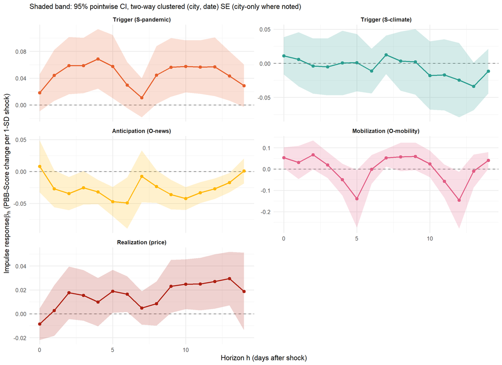

```r
if (length(missing))
  cat(sprintf("NOTE: not identified in the pooled spec: %s\n", paste(missing, collapse = ", ")))

p_base <- ggplot(base_plot_df, aes(horizon, beta, colour = category, fill = category)) +
  geom_hline(yintercept = 0, linetype = "dashed", colour = "grey50") +
  geom_ribbon(aes(ymin = ci_lo, ymax = ci_hi), alpha = 0.20, colour = NA) +
  geom_line(linewidth = 0.9) + geom_point(size = 2) +
  scale_colour_manual(values = CAT_COLORS, drop = FALSE) +
  scale_fill_manual(values = CAT_COLORS, drop = FALSE) +
  facet_wrap(~ category, ncol = 2, scales = "free_y", drop = FALSE) +
  labs(x = "Horizon h (days after shock)",
       y = expression("Impulse response " * beta[h] * " (PBB-Score change per 1-SD shock)"),
       subtitle = "Shaded band: 95% pointwise CI, two-way clustered (city, date) SE (city-only where noted)") +
  theme_minimal(base_size = 11) +
  theme(legend.position = "none", strip.text = element_text(face = "bold"))
p_base
```

```r
ggsave(file.path(LP_DIR, "lp_irf_panel.png"), p_base, width = 11, height = 8, dpi = 150)
ggsave(file.path(OUT_DIR, "PDFs", "Figure_8.pdf"), p_base, width = 11, height = 8)
```

## 7.4 Crisis-conditional impulse responses

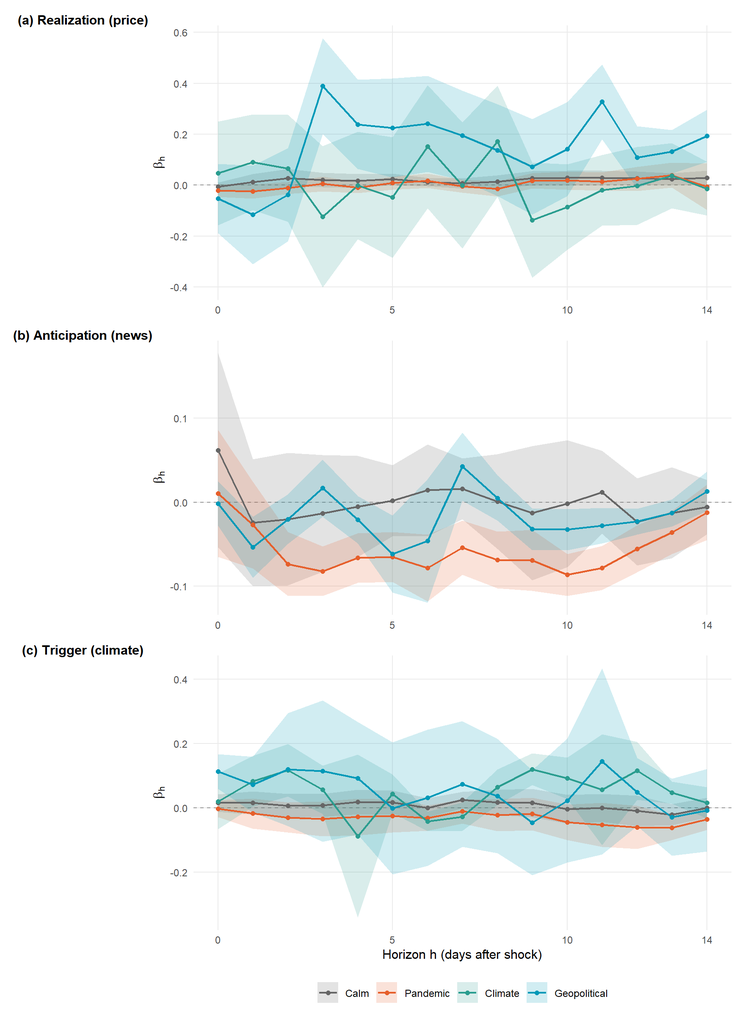

```r
crisis_cols <- c(Calm = "grey40", Pandemic = "#E65F2B",
                 Climate = "#2A9D8F", Geopolitical = "#0099B8")

build_lp_panel <- function(cn, tag, show_x = TRUE, show_legend = FALSE) {
  d <- crisis_all %>% filter(category == cn, !is.na(beta)) %>%
    mutate(crisis_type = factor(crisis_type,
                                levels = c("Calm", "Pandemic", "Climate", "Geopolitical")))
  ggplot(d, aes(horizon, beta, colour = crisis_type, fill = crisis_type)) +
    geom_hline(yintercept = 0, linetype = "dashed", colour = "grey60", linewidth = 0.4) +
    geom_ribbon(aes(ymin = ci_lo, ymax = ci_hi), alpha = 0.18, colour = NA) +
    geom_line(linewidth = 0.7) + geom_point(size = 1.4) +
    scale_colour_manual(values = crisis_cols, drop = FALSE) +
    scale_fill_manual(values  = crisis_cols, drop = FALSE) +
    scale_x_continuous(breaks = c(0, 5, 10, 14), limits = c(0, 14)) +
    labs(x = if (show_x) "Horizon h (days after shock)" else NULL,
         y = expression(beta[h]), colour = NULL, fill = NULL, tag = tag) +
    theme_minimal(base_size = 10) +
    theme(plot.tag = element_text(size = 10, face = "bold"),
          legend.position = if (show_legend) "bottom" else "none",
          panel.grid.minor = element_blank())
}

lp_a <- build_lp_panel("Realization (price)",   "(a) Realization (price)", show_x = FALSE)
lp_b <- build_lp_panel("Anticipation (O-news)", "(b) Anticipation (news)", show_x = FALSE)
lp_c <- build_lp_panel("Trigger (S-climate)",   "(c) Trigger (climate)",   show_legend = TRUE)

lp_combined <- ((lp_a / lp_b / lp_c) + plot_layout(guides = "collect")) +
  plot_annotation(theme = theme(legend.position = "bottom",
                                legend.text     = element_text(size = 10),
                                legend.margin   = margin(t = -2)))

lp_combined
```

```r
ggsave(file.path(LP_DIR, "lp_irf_crisis_combined.png"), lp_combined,
       width = 8, height = 11, dpi = 300)
ggsave(file.path(OUT_DIR, "PDFs", "Figure_9.pdf"), lp_combined, width = 8, height = 11)
```

```r
panel %>% filter(!is.na(O_mobil_dist_0_z)) %>%
  summarise(across(all_of(CRISIS_DUMMIES), sum)) %>%
  knitr::kable(caption = "Crisis-regime days with non-missing mobility data")
```

Crisis-regime days with non-missing mobility data

| crisis_pandemic | crisis_climate | crisis_geopol |
| --- | --- | --- |
| 0 | 350 | 0 |

# 8 Part 7 — Episode anatomy

Finally, the descriptive natural history. An **episode** is a maximal run of days on which a city’s PBB-Score is at or above 2σ, allowing gaps of up to two days to be bridged (a single quiet Sunday inside an otherwise continuous panic should not split one episode into two).

```r
EP_DIR <- file.path(OUT_DIR, "episode_anatomy")
EXTREME_THRESHOLD <- 3.0
GAP_TOLERANCE     <- 2

identify_runs <- function(x, gap_tolerance = 0) {
  x <- as.integer(x)
  if (gap_tolerance > 0) {
    rl <- rle(x)
    bridge <- rl$values == 0 & rl$lengths <= gap_tolerance &
      c(FALSE, head(rl$values, -1) == 1) & c(tail(rl$values, -1) == 1, FALSE)
    rl$values[bridge] <- 1
    x <- inverse.rle(rl)
  }
  rl <- rle(x)
  run_id <- rep(NA_integer_, length(x))
  if (any(rl$values == 1)) {
    starts <- cumsum(c(1, head(rl$lengths, -1)))
    ends   <- starts + rl$lengths - 1
    k <- 0
    for (j in seq_along(rl$values)) if (rl$values[j] == 1) {
      k <- k + 1; run_id[starts[j]:ends[j]] <- k
    }
  }
  run_id
}
```

```r
ep_df <- read.csv2(PANEL_CSV, fileEncoding = "UTF-8")
ep_df$date <- as.Date(ep_df$date)
ep_df <- ep_df %>% filter(!is.na(API)) %>% arrange(city, date) %>%
  mutate(panic_flag   = as.integer(API >= PANIC_THRESHOLD),
         extreme_flag = as.integer(API >= EXTREME_THRESHOLD))

episodes <- ep_df %>%
  group_by(city) %>%
  mutate(episode_id = identify_runs(panic_flag, GAP_TOLERANCE)) %>%
  ungroup() %>%
  filter(!is.na(episode_id)) %>%
  group_by(city, episode_id) %>%
  summarise(start_date    = min(date),
            end_date      = max(date),
            duration_days = as.integer(end_date - start_date) + 1L,
            n_panic_days  = sum(panic_flag, na.rm = TRUE),
            peak_PBB      = max(API, na.rm = TRUE),
            mean_PBB      = mean(API[panic_flag == 1], na.rm = TRUE),
            is_extreme    = as.integer(any(extreme_flag == 1, na.rm = TRUE)),
            .groups = "drop") %>%
  mutate(year = year(start_date))

# An episode is labelled by a crisis type if its interval OVERLAPS any window of that type.
# The regime calendar (with the documented v9 omissions) is reused from Part 6.
overlaps <- function(s, e, cal) {
  Reduce(`|`, Map(function(ws, we) s <= we & e >= ws, cal$start, cal$end))
}

episodes <- episodes %>%
  mutate(is_pandemic = overlaps(start_date, end_date, by_type$pandemic),
         is_climate  = overlaps(start_date, end_date, by_type$climate),
         is_geopol   = overlaps(start_date, end_date, by_type$geopolitical),
         # Prioritised label: acute (climate/geopolitical) overrides chronic (pandemic)
         crisis_type = case_when(is_climate  ~ "Climate",
                                 is_geopol   ~ "Geopolitical",
                                 is_pandemic ~ "Pandemic",
                                 TRUE        ~ "Unattributed"))

write.csv(episodes, file.path(EP_DIR, "episode_table.csv"), row.names = FALSE)

cat(sprintf("Episodes identified: %d across %d municipalities\n",
            nrow(episodes), n_distinct(episodes$city)))
```

```
## Episodes identified: 1132 across 15 municipalities
```

The prioritised label needs justification. The pandemic windows span years, so almost every climate or geopolitical episode in 2020–2022 *also* falls inside a pandemic window. Attributing those to “pandemic” would make the pandemic look like the cause of everything. We therefore let the **acute, short-window** hazard take precedence over the **chronic, long-window** one.

```r
ep_summary <- data.frame(
  Metric = c("Total episodes", "Municipalities with >= 1 episode",
             "Mean duration (days)", "Median duration (days)", "Max duration (days)",
             "Mean peak PBB-Score", "Episodes containing an extreme (>= 3σ) day",
             "Episodes per city-year"),
  Value = c(nrow(episodes),
            n_distinct(episodes$city),
            round(mean(episodes$duration_days), 2),
            median(episodes$duration_days),
            max(episodes$duration_days),
            round(mean(episodes$peak_PBB), 2),
            sum(episodes$is_extreme),
            round(nrow(episodes) / (n_distinct(episodes$city) * n_distinct(episodes$year)), 2))
)
knitr::kable(ep_summary, row.names = FALSE, caption = "Episode anatomy — headline statistics")
```

Episode anatomy — headline statistics

| Metric | Value |
| --- | --- |
| Total episodes | 1132.00 |
| Municipalities with >= 1 episode | 15.00 |
| Mean duration (days) | 1.81 |
| Median duration (days) | 1.00 |
| Max duration (days) | 37.00 |
| Mean peak PBB-Score | 3.15 |
| Episodes containing an extreme (>= 3σ) day | 483.00 |
| Episodes per city-year | 9.43 |

```r
ct <- episodes %>% count(crisis_type) %>%
  mutate(share = sprintf("%.1f%%", 100 * n / sum(n))) %>% arrange(desc(n))
knitr::kable(ct, col.names = c("Crisis context", "Episodes", "Share"),
             caption = "Episodes by crisis attribution (prioritised labelling)")
```

Episodes by crisis attribution (prioritised labelling)

| Crisis context | Episodes | Share |
| --- | --- | --- |
| Unattributed | 718 | 63.4% |
| Pandemic | 377 | 33.3% |
| Climate | 35 | 3.1% |
| Geopolitical | 2 | 0.2% |

## 8.1 Sensitivity to the gap tolerance

```r
gap_tab <- do.call(rbind, lapply(c(0, 1, 2, 5), function(g) {
  n <- ep_df %>% group_by(city) %>%
    mutate(eid = identify_runs(panic_flag, g)) %>% ungroup() %>%
    filter(!is.na(eid)) %>% distinct(city, eid) %>% nrow()
  data.frame(`Gap tolerance (days)` = g, Episodes = n, check.names = FALSE)
}))
knitr::kable(gap_tab, row.names = FALSE,
             caption = "Episode count as a function of the gap-bridging tolerance")
```

Episode count as a function of the gap-bridging tolerance

| Gap tolerance (days) | Episodes |
| --- | --- |
| 0 | 1326 |
| 1 | 1209 |
| 2 | 1132 |
| 5 | 962 |

## 8.2 Figures

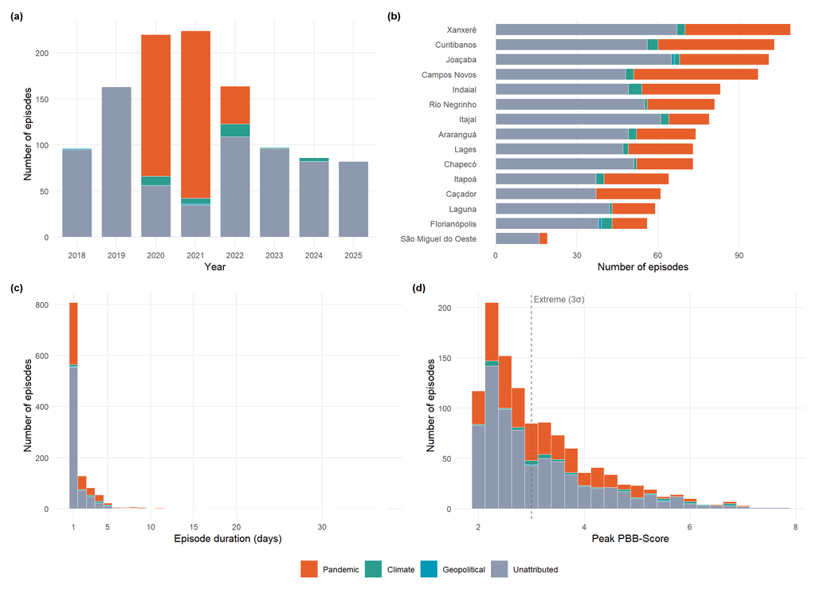

```r
crisis_colors <- c(Pandemic = "#E65F2B", Climate = "#2A9D8F",
                   Geopolitical = "#0099B8", Unattributed = "#8D99AE")

# Pin the crisis_type factor so every panel uses the same four levels / colours,
# whether or not a given panel actually contains all of them.
episodes <- episodes %>%
  mutate(crisis_type = factor(crisis_type,
                              levels = c("Pandemic", "Climate", "Geopolitical", "Unattributed")))

# (a) episodes per year, stacked by crisis type
p_year <- episodes %>% count(year, crisis_type, .drop = FALSE) %>%
  ggplot(aes(factor(year), n, fill = crisis_type)) +
  geom_col(width = 0.75, colour = "white", linewidth = 0.3) +
  scale_fill_manual(values = crisis_colors, drop = FALSE) +
  labs(x = "Year", y = "Number of episodes", fill = NULL, tag = "(a)") +
  theme_minimal(base_size = 10) +
  theme(plot.tag = element_text(size = 10, face = "bold"),
        legend.position = "none", panel.grid.minor = element_blank())

# (b) episodes per city, sorted, stacked by crisis type
city_order   <- episodes %>% count(city) %>% arrange(n) %>% pull(city)
p_city <- episodes %>% count(city, crisis_type, .drop = FALSE) %>%
  mutate(city = factor(city, levels = city_order)) %>%
  ggplot(aes(city, n, fill = crisis_type)) +
  geom_col(width = 0.75, colour = "white", linewidth = 0.3) +
  scale_fill_manual(values = crisis_colors, drop = FALSE) +
  coord_flip() +
  labs(x = NULL, y = "Number of episodes", fill = NULL, tag = "(b)") +
  theme_minimal(base_size = 10) +
  theme(plot.tag = element_text(size = 10, face = "bold"),
        legend.position = "none", panel.grid.major.y = element_blank(),
        panel.grid.minor = element_blank())

# (c) duration distribution — a STACKED histogram coloured by crisis type
#     (not a single-colour histogram)
p_dur <- ggplot(episodes, aes(duration_days, fill = crisis_type)) +
  geom_histogram(binwidth = 1, colour = "white", linewidth = 0.2) +
  scale_fill_manual(values = crisis_colors, drop = FALSE) +
  scale_x_continuous(breaks = c(1, 5, 10, 15, 20, 30)) +
  labs(x = "Episode duration (days)", y = "Number of episodes",
       fill = NULL, tag = "(c)") +
  theme_minimal(base_size = 10) +
  theme(plot.tag = element_text(size = 10, face = "bold"),
        legend.position = "none", panel.grid.minor = element_blank())

# (d) peak-intensity distribution — a histogram of peak PBB coloured by crisis type,
#     with the 3σ extreme line (this is a distribution, NOT a duration-vs-peak scatter)
p_sev <- ggplot(episodes, aes(peak_PBB, fill = crisis_type)) +
  geom_histogram(binwidth = 0.25, colour = "white", linewidth = 0.2) +
  geom_vline(xintercept = EXTREME_THRESHOLD, linetype = "dashed",
             colour = "grey40", linewidth = 0.4) +
  annotate("text", x = EXTREME_THRESHOLD, y = Inf, label = " Extreme (3σ)",
           hjust = 0, vjust = 1.5, size = 3, colour = "grey40") +
  scale_fill_manual(values = crisis_colors, drop = FALSE) +
  labs(x = "Peak PBB-Score", y = "Number of episodes", fill = NULL, tag = "(d)") +
  theme_minimal(base_size = 10) +
  theme(plot.tag = element_text(size = 10, face = "bold"),
        legend.position = "bottom", panel.grid.minor = element_blank())

# Composition-level legend via plot_annotation (ggplot2 4.x-safe; no `&` on patchwork)
ep_panel <- ((p_year + p_city) / (p_dur + p_sev)) +
  plot_layout(guides = "collect") +
  plot_annotation(theme = theme(legend.position = "bottom",
                                legend.text   = element_text(size = 10),
                                legend.margin = margin(t = -4)))
ep_panel
```

```r
ggsave(file.path(EP_DIR, "episode_anatomy_panel.png"), ep_panel,
       width = 11, height = 8, dpi = 300)
ggsave(file.path(OUT_DIR, "PDFs", "Figure_3.pdf"), ep_panel, width = 11, height = 8)
```

# 9 Reproducibility

Every table and figure above is generated by this document. The canonical model outputs used in the manuscript are:

Canonical outputs

| Artefact | Path |
| --- | --- |
| Regression comparison (headline) | data/analysis//temporal_cv_ar_augmented/comparison_summary.csv |
| Per-fold regression metrics | data/analysis//temporal_cv_ar_augmented/comparison_fold_metrics.csv |
| Early-warning comparison | data/analysis//classification_three_way/comparison_summary.csv |
| Per-fold classification metrics | data/analysis//classification_three_way/metrics_per_fold.csv |
| Hyperparameter-transfer sensitivity | data/analysis//hyperparam_sensitivity.csv |
| Local Projection IRFs | data/analysis//local_projections/lp_irf_by_crisis.csv |
| Episode table | data/analysis//episode_anatomy/episode_table.csv |
| Processed modelling panel | data/input//3_Final_data_With_Time_modification_ADDED_Var.csv |

## 9.1 Data availability

The SEF/SC *Nota Fiscal* transaction data underlying `total_sales_value_daily` are provided by the Santa Catarina State Treasury. All other inputs are public: IBGE/SIDRA (IPCA food sub-index, population), Google Trends, INMET (meteorology), Meta Movement Distribution Maps (mobility, 2022 onward), and Globo/G1 headline counts.